# Insurance Fraud

```python
plt.clf()
```

Observations with Label 1(Anomaly = yes) have anomaly scores under zero as opposed to observations with label 0 (Anomaly = no) which have scores above zero.

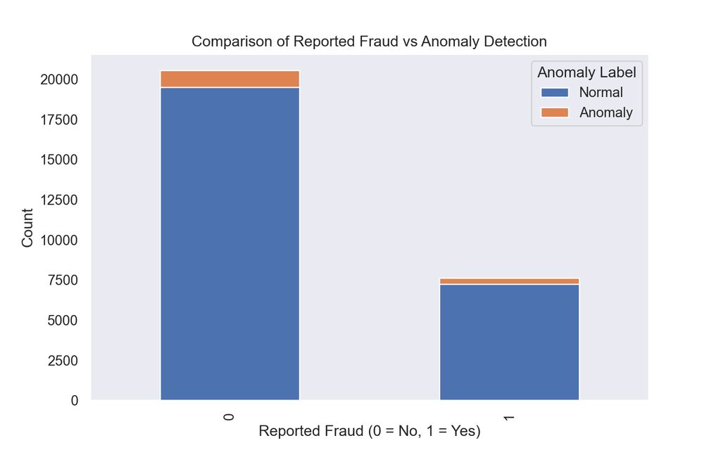

```python
with contextlib.redirect_stderr(sys.stdout):
  # Compare fraud cases vs anomaly detection
  fraud_anomalies = processed_df_2.groupby(['ReportedFraud', 'Anomaly_Label']).size().unstack()
  fraud_anomalies.plot(kind='bar', stacked=True, figsize=(8, 5))
  plt.xlabel('Reported Fraud (0 = No, 1 = Yes)')
  plt.ylabel('Count')
  plt.title('Comparison of Reported Fraud vs Anomaly Detection')
  plt.legend(title="Anomaly Label", labels=['Normal', 'Anomaly'])

  plt.show()
  plt.clf()
```

```python
from sklearn.tree import DecisionTreeClassifier
```

```python
# Feature importance using Decision Tree as a surrogate model
tree_model = DecisionTreeClassifier(random_state=42)
tree_model.fit(processed_df_2[feature_columns], processed_df_2['Anomaly_Label'])
```

```
DecisionTreeClassifier(random_state=42)
```

```python
feature_importance = pd.DataFrame({
    'Feature': feature_columns,
    'Importance': tree_model.feature_importances_
}).sort_values(by='Importance', ascending=False).round(3)
```

```python
feat_out_tp5=feature_importance.nlargest(5,"Importance")
```

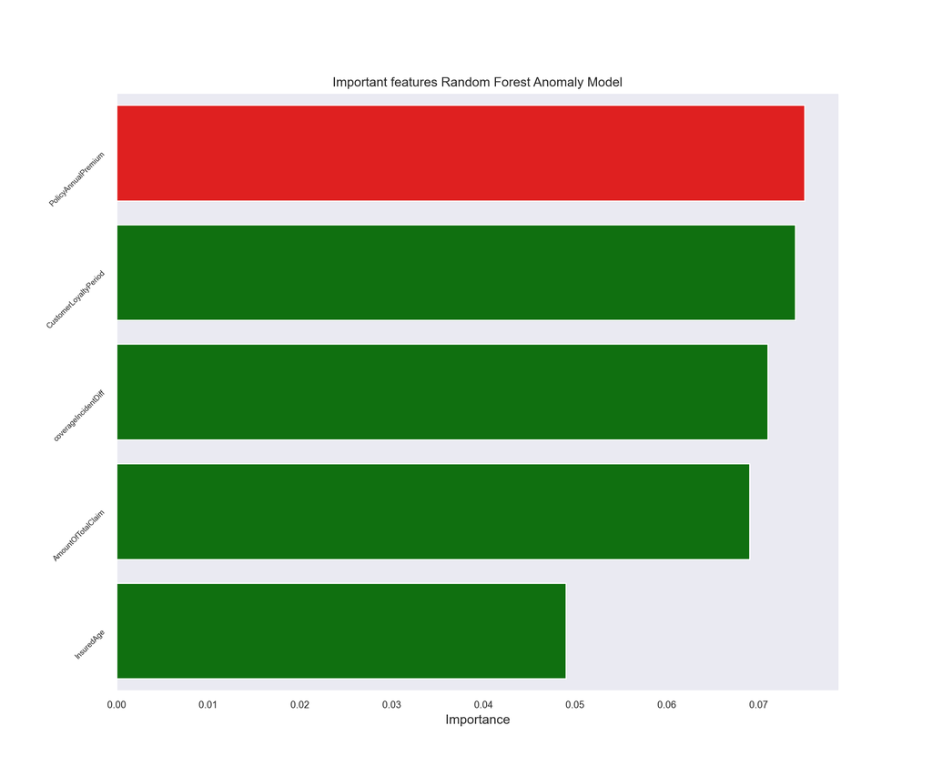

```python
values = feat_out_tp5.Importance
idx = feat_out_tp5.Feature
plt.figure(figsize=(12,10))
clrs = ['green' if (x < max(values)) else 'red' for x in values ]
sns.barplot(y=idx,x=values,palette=clrs).set(title='Important features Random Forest Anomaly Model')

plt.ylabel("Features", fontsize=510)

plt.tick_params(axis='x', which='major', labelsize=9)

plt.tick_params(axis='y', labelsize=7,labelrotation=45)

plt.show()
```

```python
plt.clf()
```

Feature Importance is a score assigned to features that defines how “important” a feature is to the model’s prediction. This means the extent to which the feature contributes to the final output. However, feature importance does not inform us if the contribution is a positive or negative impact on the final output.

In our inspection of these top features in the visualization section, the distribution between fraud and no fraud did not show differences in distribution. In order to thoroughly perform anomaly detection, we woujld include other model algorithms. Since the focus of this project is predicting fraud, anomaly detection will be a seperate project.

# Data Preprocessing

Before model building can start, we’ll need to perform pre-processing. This will entail splitting our data into training, validation, and test sets along with transforming numerical and categorical features into classification friendly formats.

Select features

```
## The  Target categories: Index(['N', 'Y'], dtype='object'):
```

Will relocate ReportedFraud feature to the last index of the model_data

```python
col=model_data.pop('ReportedFraud')
model_data.insert(22,'ReportedFraud', col)
```

## Split Dateset

We will separate the data to get predictor features and target features into separate data frames.

```python
model_data2=model_data2.rename(columns={'ReportedFraud': 'labels'})
```

The data type of the target feature is categorical. Most machine learning algorithms require numerical data types. The target feature y will transformed to a numeric tpye.

```python
label_encoder=LabelEncoder()
```

```python
def split_data(data):
  y=data.iloc[:, -1]
  y=pd.DataFrame(y)
  y['labels']=label_encoder.fit_transform(y['labels'])
  y['labels']=y['labels'].astype("category")
  X=data.iloc[:, :-1]

  return X, y
```

```python
X,y=split_data(model_data2)
```

```
## CategoricalDtype(categories=[0, 1], ordered=False)
```

```
## Target Feature categories as binary:  Int64Index([0, 1], dtype='int64'):
```

[output not shown]

```
## Shape of Target Feature is (28181, 1):
```

```
## *********** X Structure***********
```

```
## <class 'pandas.core.frame.DataFrame'>
## Int64Index: 28181 entries, 0 to 28835
## Data columns (total 23 columns):
##  #   Column                      Non-Null Count  Dtype
## ---  ------                      --------------  -----
##  0   TypeOfIncident              28181 non-null  category
##  1   TypeOfCollission            28181 non-null  category
##  2   SeverityOfIncident          28181 non-null  category
##  3   AuthoritiesContacted        28181 non-null  category
##  4   IncidentState               28181 non-null  category
##  5   NumberOfVehicles            28181 non-null  category
##  6   BodilyInjuries              28181 non-null  category
##  7   Witnesses                   28181 non-null  category
##  8   AmountOfTotalClaim          28181 non-null  int32
##  9   InsuredAge                  28181 non-null  int32
##  10  InsuredGender               28181 non-null  category
##  11  CapitalGains                28181 non-null  int32
##  12  CapitalLoss                 28181 non-null  int32
##  13  CustomerLoyaltyPeriod       28181 non-null  int32
##  14  InsurancePolicyState        28181 non-null  category
##  15  Policy_CombinedSingleLimit  28181 non-null  category
##  16  Policy_Deductible           28181 non-null  int32
##  17  PolicyAnnualPremium         28181 non-null  float64
##  18  UmbrellaLimit               28181 non-null  int32
##  19  InsuredRelationship         28181 non-null  category
##  20  coverageIncidentDiff        28181 non-null  float64
##  21  dayOfWeek                   28181 non-null  category
##  22  IncidentPeriodDay           28181 non-null  category
## dtypes: category(14), float64(2), int32(7)
## memory usage: 1.8 MB
```

## Train/Test sets

We will now split X,y into Train and Test sets

```python
X_train, X_test, y_train, y_test=train_test_split(X,y, test_size=0.25,random_state=42, stratify=y)
```

```
## Shape of X Train: (21135, 23)
```

```
## Shape of X Test: (7046, 23)
```

```
## Shape of y Train: (21135, 1)
```

```
## Shape of y Test: (7046, 1)
```

y train and y test will be transformed into one dimensional arrays using a function.

```python
def transform_to_array(y_train, y_test):
  #transform from data frame to numpy array
  y_train_array=np.array(y_train)
  y_test_array=np.array(y_test)
  #transform to one dimensianal array
  y_train_np=np.ravel(y_train_array)
  y_test_np=np.ravel(y_test_array)

  return y_train_np, y_test_np
```

```python
y_train_np, y_test_np=transform_to_array(y_train, y_test)
```

```
## Shape of y Train np: (21135,)
```

```
## Shape of y Test np: (7046,)
```

From the above output we see that y train and y test have been transformed into one dimensional numpy arrays.

## Transform Categorical and Numerical features

Our next step is to transform the predictor features into acceptable machine learning formats.

Transformation for numerical features is performed by scaling. Scaling prevents a feature with a range let’s say in the thousands from being considered more important than a feature having a lower range. Scaling places features at the same importance before being applied to a machine learning algorithm. There are different methods used in scaling features, for this analysis we’ll be using standard scaling. Standard scaling transforms the data to have zero mean and a variance of one, thus making the data unitless.

Most machine learning algorithms only accept numerical features which makes categorical features unacceptable in their original form. Thus, we need to encode categorical features into numerical values. The act of replacing categories with numbers is called categorical encoding. For this we will use one-hot encoding. Categorical features are represented as a group of binary features, where each binary feature represents one category. The binary feature takes the integer value 1 if the category is present, or 0 otherwise.

set_config configures pre-processing steps such as Standard Scaler and One Hot Encoding to return a Pandas Data Frame

```python
set_config(transform_output="pandas")
```

```python
def define_columns(X_train):
  categorical= list(X_train.select_dtypes('category').columns)
  numerical = list(X_train.select_dtypes('number').columns)

  return categorical, numerical
```

```python
categorical, numerical=define_columns(X_train)
```

First, we will create a function which will transform train and test sets for the Logistic Regression model. This entails dropping the first category of each feature during One Hot Encoding.

```python
def transform_x_columns(X_train, X_test):
  ct_lr=ColumnTransformer(
  transformers=[
   ('scale',StandardScaler(), numerical),
   ('ohe',OneHotEncoder(handle_unknown='ignore', sparse_output=False, drop='first'), categorical)])
  X_train_lr=ct_lr.fit_transform(X_train)
  X_test_lr=ct_lr.transform(X_test)

  return X_train_lr, X_test_lr
```

```python
with contextlib.redirect_stderr(sys.stdout):
  X_train_lr, X_test_lr=transform_x_columns(X_train, X_test)
```

```
## ********************First Five Rows X_train_lr********************
```

```
##        scale__AmountOfTotalClaim  scale__InsuredAge  scale__CapitalGains
## 3409                   -1.852393          -1.614806             1.582364
## 19726                  -0.207519          -0.234876             1.636523
## 9912                    0.171842           1.395950             1.174367
## 5686                   -1.839096           0.266916             1.156314
## 11372                  -1.850651           1.395950             1.022723
```

```
## ********************First Five Rows X_test_lr********************
```

```
##        scale__AmountOfTotalClaim  scale__InsuredAge  scale__CapitalGains
## 7225                   -0.329962          -1.238462             1.224916
## 15229                  -0.220341          -0.611221             1.062439
## 24504                   0.747730          -0.987565             1.037165
## 14811                   1.059300          -0.485773            -0.836730
## 14954                   0.421042          -0.987565             1.701513
```

We will confirm that the columns of X_train_lr and X_test_lr are the same count after transformation

```python
# Function to check column count
def check_columns_equal(df1, df2):
    assert df1.shape[1] == df2.shape[1], f"Error: Column counts do not match. df1 has {df1.shape[1]} columns, df2 has {df2.shape[1]} columns."
    print("Columns are equal.")
```

```python
check_columns_equal(X_train_lr, X_test_lr)
```

```
## Columns are equal.
```

We see from the first five rows of the train, valid, and test sets that the features have been transformed while at the same time retaining the column feature names.

```
## Shape of X Train lr: (21135, 63)
```

```
## Shape of X Test lr: (7046, 63)
```

Next, we transform training, valid, and test sets for all other models. During One Hot Encoding, the first category will be dropped only if the feature is binary.

```python
def transform_x_columns_tr(train, test):
  ct_tr=ColumnTransformer(
  transformers=[
   ('num',StandardScaler(), numerical),
   ('cat',OneHotEncoder(handle_unknown='ignore', sparse_output=False, drop='if_binary'), categorical)])
  train_tr=ct_tr.fit_transform(train)
  test_tr=ct_tr.transform(test)

  return train_tr, test_tr
```

```python
X_train_tr, X_test_tr=transform_x_columns_tr(X_train, X_test)
```

```
## ************First Five Rows X_train_tr************
```

```
##        num__AmountOfTotalClaim  num__InsuredAge  num__CapitalGains
## 3409                 -1.852393        -1.614806           1.582364
## 19726                -0.207519        -0.234876           1.636523
## 9912                  0.171842         1.395950           1.174367
## 5686                 -1.839096         0.266916           1.156314
## 11372                -1.850651         1.395950           1.022723
```

```
## ********************First Five Rows X_test_tr********************
```

```
##        num__AmountOfTotalClaim  num__InsuredAge  num__CapitalGains
## 7225                 -0.329962        -1.238462           1.224916
## 15229                -0.220341        -0.611221           1.062439
## 24504                 0.747730        -0.987565           1.037165
## 14811                 1.059300        -0.485773          -0.836730
## 14954                 0.421042        -0.987565           1.701513
```

We will confirm that the X_train_tr and X_test_tr columns count are equal

```python
check_columns_equal(X_train_tr, X_test_tr)
```

```
## Columns are equal.
```

```
## Shape of X Train tr: (21135, 76)
```

```
## Shape of X Test tr: (7046, 76)
```

From the shape output we find there are 13 additional columns compared to the logistic regression transformed data.

For evaluating model performance, the event of interest we are interested in is if reported fraud is yes. This is considered the positive class. Classification metrics are used to determine how well our models predict the event of interest.

# Metrics Definitions

Accuracy-measures the number of predictions that are correct as a percentage of the total number of predictions that are made. As an example, if 90% of your predictions are correct, your accuracy is simply 90%. Calculation: number of correct predictions/Number of total predictions. TP+TN/(TP+TN+FP+FN)

Precision-tells us about the quality of positive predictions. It may not find all the positives but the ones that the model does classify as positive are very likely to be correct. As an example, out of everyone predicted to have defaulted, how many of them did default? So, within everything that has been predicted as a positive, precision counts the percentage that is correct. Calculation: True positives/All Positives. TP/(TP+FP)

Recall- tells us about how well the model identifies true positives. The model may find a lot of positives, yet it also will wrongly detect many positives that are not actually positives. Out of all the patients who have the disease, how many were correctly identified? So, within everything that is positive, how many did the model successfully to find. A model with low recall is not able to find all (or a large part) of the positive cases in the data. Calculated as: True Positives/(False Negatives + True Positives)

F1 Score-The F1 score is defined as the harmonic mean of precision and recall.

The harmonic mean is an alternative metric for the more common arithmetic mean. It is often useful when computing an average rate. https://en.wikipedia.org/wiki/Harmonic_mean

The formula for the F1 score is the following: 2 times((precision*Recall)/(Precision + Recall))

Since the F1 score is an average of Precision and Recall, it means that the F1 score gives equal weight to Precision and Recall:

```python
recall_scorer = make_scorer(recall_score, pos_label=1)

precision_scorer = make_scorer(precision_score, pos_label=1)

roc_auc_scorer = make_scorer(roc_auc_score)
```

# Model Training

## Logistic Regression

### Base Model

```python
skf = StratifiedKFold(n_splits=10, shuffle=True, random_state=1)
```

```python
lr_base_clf=logreg.fit(X_train_lr, y_train_np)
```

```python
start_time = time.time()

lr_base_cv_accuracy=cross_val_score(lr_base_clf, X_train_lr, y_train_np, cv=skf, scoring='accuracy').mean().round(2)
log_CrossValAccurBase_time = time.time() - start_time
```

```python
start_time = time.time()
lr_base_cv_recall_score=cross_val_score(lr_base_clf, X_train_lr, y_train_np,
scoring=recall_scorer, cv=skf, n_jobs=-1).mean().round(2)
log_CrossValRecallBase_time = time.time() - start_time
```

```python
start_time = time.time()
lr_base_cv_precision_score=cross_val_score(lr_base_clf, X_train_lr, y_train_np,
scoring=precision_scorer, cv=skf, n_jobs=-1).mean().round(2)
log_CrossValPrecBase_time = time.time() - start_time
```

```python
start_time = time.time()
lr_base_cv_auc_score=cross_val_score(lr_base_clf, X_train_lr, y_train_np,
scoring=roc_auc_scorer, cv=skf, n_jobs=-1).mean().round(2)
log_CrossValAUCBase_time = time.time() - start_time
```

```python
start_time = time.time()
lr_base_cv_f1=cross_val_score(lr_base_clf, X_train_lr, y_train_np, cv=skf, scoring='f1').mean().round(2)
log_CrossValF1Base_time = time.time() - start_time
```

### Cross Validation with Paramters

```python
lr=LogisticRegression(random_state=1)
```

```python
lr_params={
'C': [0.0001,0.001, 0.01, 0.1, 1, 10],
'penalty': ['l2'],
'max_iter': list(range(5000,40000, 5000)),
'solver': ['newton-cg', 'lbfgs', 'liblinear', 'sag', 'saga']

}
```

```python
lr_search=RandomizedSearchCV(lr, lr_params, refit=True,
verbose=3,cv=5,n_iter=6,scoring='roc_auc',return_train_score=True, n_jobs=-1)
```

```python
start_time = time.time()
lr_search.fit(X_train_lr, y_train_np)
```

```
RandomizedSearchCV(cv=5, estimator=LogisticRegression(random_state=1), n_iter=6,
                   n_jobs=-1,
                   param_distributions={'C': [0.0001, 0.001, 0.01, 0.1, 1, 10],
                                        'max_iter': [5000, 10000, 15000, 20000,
                                                     25000, 30000, 35000],
                                        'penalty': ['l2'],
                                        'solver': ['newton-cg', 'lbfgs',
                                                   'liblinear', 'sag',
                                                   'saga']},
                   return_train_score=True, scoring='roc_auc', verbose=3)
```

```python
log_grid_training_time = time.time() - start_time
```

```python
lr_cv_results=pd.DataFrame(lr_search.cv_results_)
```

```python
lr_cv_results[['mean_train_score', 'std_train_score','mean_test_score', 'std_test_score']].mean()
```

```
## mean_train_score    0.769316
## std_train_score     0.001226
## mean_test_score     0.765394
## std_test_score      0.004892
## dtype: float64
```

Mean train and test scores from cross validation indicate no over-fitting or under-fitting.

```python
lr_clf=lr_search.best_estimator_
```

```
LogisticRegression(C=1, max_iter=30000, random_state=1, solver='newton-cg')
```

The above displays gives us the parameters chosen for the logistic regression model.

```python
start_time = time.time()
lr_cv_accuracy=cross_val_score(lr_clf, X_train_lr, y_train_np,
scoring='accuracy', cv=skf, n_jobs=-1).mean().round(2)
log_CrossValAccur_time = time.time() - start_time
```

```python
start_time = time.time()
lr_cv_f1_score=cross_val_score(lr_clf, X_train_lr, y_train_np,
scoring='f1', cv=skf, n_jobs=-1).mean().round(2)

log_CrossValF1_time = time.time() - start_time
```

```python
start_time = time.time()

lr_cv_recall_score=cross_val_score(lr_clf, X_train_lr, y_train_np,
scoring=recall_scorer, cv=skf, n_jobs=-1).mean().round(2)
log_CrossValRecall_time = time.time() - start_time
```

```python
start_time = time.time()
lr_cv_precision_score=cross_val_score(lr_clf, X_train_lr, y_train_np,
scoring=precision_scorer, cv=skf, n_jobs=-1).mean().round(2)
log_CrossValPrec_time = time.time() - start_time
```

```python
start_time = time.time()
lr_cv_auc_score=cross_val_score(lr_clf, X_train_lr, y_train_np,
scoring=roc_auc_scorer, cv=skf, n_jobs=-1).mean().round(2)
log_CrossValAuc_time = time.time() - start_time
```

```python
log_cross_val_Time=(log_CrossValAccur_time+log_CrossValRecall_time+log_CrossValF1_time+ log_CrossValPrec_time+log_CrossValAuc_time)/5
```

### Metrics and Feature Importance

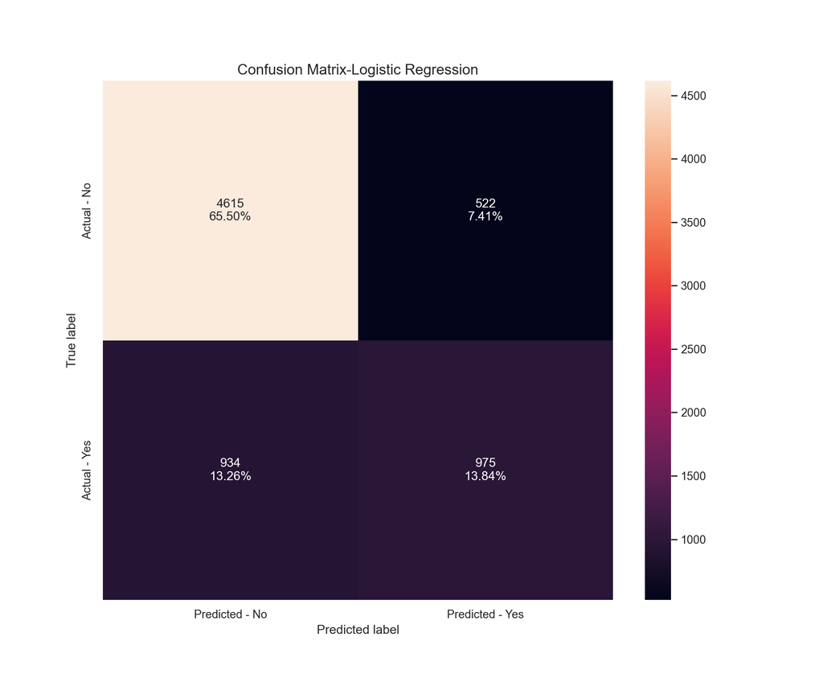

```python
cm_lr = metrics.confusion_matrix(y_test_np, y_pred_lr, labels=[0,1])
df_cm_lr = pd.DataFrame(cm_lr, index=["Actual - No", "Actual - Yes"], columns=["Predicted - No", "Predicted - Yes"])
group_counts = ["{0:0.0f}".format(value) for value in cm_lr.flatten()]
group_percentages = ["{0:.2%}".format(value) for value in cm_lr.flatten()/np.sum(cm_lr)]
labels = [f"{v1}\n{v2}" for v1, v2 in zip(group_counts, group_percentages)]
labels = np.asarray(labels).reshape(2,2)

plt.figure(figsize=(11,9))
sns.heatmap(df_cm_lr, annot=labels, fmt='')
plt.ylabel('True label')
plt.xlabel('Predicted label')

plt.title("Confusion Matrix-Logistic Regression", fontsize=14)

plt.show()
```

```python
plt.clf()
```

We see from the confusion matrix that 13.84% of fraud predictions were accurately predicted as Yes compared to 7.41% that were inaccurately predicted as yes.

We will now look at Feature Importance. Feature Importance is a score assigned to the features of a Machine Learning model that defines how “important” is a feature to the model’s prediction. This means the extent to which the feature contributes to the final output. However, feature importance does not inform us if the contribution is a positive or negative impact on the final output.

```python
feature_importance_lr=pd.DataFrame({'feature':list(X_test_lr.columns),'feature_importance':[abs(i) for i in lr_clf.coef_[0]]})


feature_importance_lr=feature_importance_lr.sort_values('feature_importance',ascending=False)
```

For the logistical regression model we took the absolute value of the coefficients so as to get the Importance of the feature both with negative and positive effect.

Now that we have the importance of the features, we will now transform the coefficients for easier interpretation. The coefficients are in log odds format. We will transform them to odds-ratio format.

```python
#Combine feature names and coefficients on top Pandas DataFrame
feature_names_lr=pd.DataFrame(X_test_lr.columns, columns=['Feature'])

log_coef=pd.DataFrame(np.transpose(lr_clf.coef_), columns=['Coefficent'])

coefficients=pd.concat([feature_names_lr, log_coef], axis=1)
```

```python
#Calculate exponent of the logistic regression coefficients

coefficients['Exp_Coefficient']=np.exp(coefficients['Coefficent'])
```

```python
#Remove coefficients that are equal to zero.

coefficients=coefficients[coefficients['Exp_Coefficient']>=1]
```

```python
coefficients_tp5=coefficients.nlargest(5,"Exp_Coefficient")
```

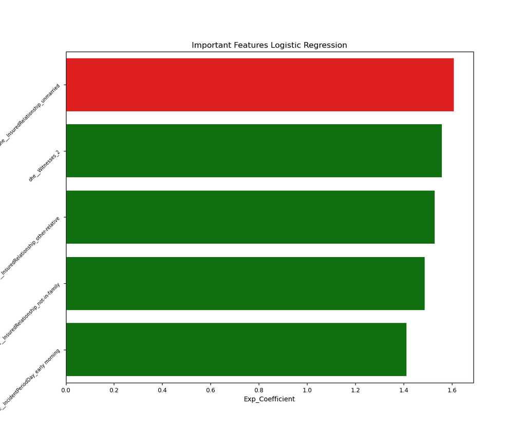

```r
knitr::include_graphics("logReg_feat_import.png")
```

## Support Vector Machine

Support Vector Machine (the “road machine”) is responsible for finding the decision boundary to separate different classes and maximize the margin. A decision boundary differentiates two classes. A data point falling on either side of the decision boundary can be attributed to different classes. Binary classes would be either yes or no.

```python
from sklearn.svm import SVC
```

### Base Model

```python
svc=SVC(random_state=1, kernel="rbf")
```

```python
svc_base_clf=svc.fit(X_train_lr, y_train_np)
```

```python
start_time = time.time()
svc_base_cv_accuracy=cross_val_score(svc_base_clf, X_train_lr, y_train_np, cv=skf, scoring='accuracy').mean().round(2)
svc_CrossValAccurBase_time = time.time() - start_time
```

```python
start_time = time.time()
svc_base_cv_recall=cross_val_score(svc_base_clf, X_train_lr, y_train_np, cv=skf, scoring=recall_scorer, n_jobs=-1).mean().round(2)
svcBase_CrossValRcall = time.time() - start_time
```

```python
start_time = time.time()
svc_base_cv_precision=cross_val_score(svc_base_clf, X_train_lr, y_train_np, cv=skf, scoring=precision_scorer, n_jobs=-1).mean().round(2)
svcBase_CrossValprec = time.time() - start_time
```

```python
start_time = time.time()
svc_base_cv_f1=cross_val_score(svc_base_clf, X_train_lr, y_train_np, cv=skf, scoring='f1', n_jobs=-1).mean().round(2)
svcBase_CrossValF1 = time.time() - start_time
```

```python
start_time = time.time()
svc_base_cv_auc_score=cross_val_score(svc_base_clf, X_train_lr, y_train_np,
scoring=roc_auc_scorer, cv=skf, n_jobs=-1).mean().round(2)
svcBase_CrossValAuc = time.time() - start_time
```

```python
svcBase_cross_val_Time=(svc_CrossValAccurBase_time+svcBase_CrossValRcall+svcBase_CrossValF1+ svcBase_CrossValprec+svcBase_CrossValAuc)/5
```

### Cross validation with paramters

```python
param_grid_svc = {'C': [0.0001,.001,.01,1, 10, 100], 'gamma': [1,0.1,0.01,0.001, .0001]}
```

```python
grid_svc=RandomizedSearchCV(svc,param_grid_svc, refit=True,
verbose=3,cv=5,n_iter=6, scoring='roc_auc',return_train_score=True, n_jobs=-1)
```

```python
start_time = time.time()
grid_svc.fit(X_train_lr, y_train_np)
```

```
RandomizedSearchCV(cv=5, estimator=SVC(random_state=1), n_iter=6, n_jobs=-1,
                   param_distributions={'C': [0.0001, 0.001, 0.01, 1, 10, 100],
                                        'gamma': [1, 0.1, 0.01, 0.001, 0.0001]},
                   return_train_score=True, scoring='roc_auc', verbose=3)
```

```python
svc_grid_training_time = time.time() - start_time
```

```python
svc_cv_results=pd.DataFrame(grid_svc.cv_results_)
```

```python
svc_cv_results[['mean_train_score', 'std_train_score','mean_test_score', 'std_test_score']].mean()
```

```
## mean_train_score    0.887926
## std_train_score     0.001169
## mean_test_score     0.838609
## std_test_score      0.004844
## dtype: float64
```

```python
svc_clf=grid_svc.best_estimator_
```

```
SVC(C=10, gamma=0.1, random_state=1)
```

The above displays gives us the parameters chosen for the support vector machine Model.

```python
start_time = time.time()
svc_cv_accuracy=cross_val_score(svc_clf, X_train_lr, y_train_np,
scoring='accuracy', cv=skf, n_jobs=-1).mean().round(2)
svc_CrossValAccur_time = time.time() - start_time
```

```python
start_time = time.time()
svc_cv_f1_score=cross_val_score(svc_clf, X_train_lr, y_train_np,
scoring='f1', cv=skf, n_jobs=-1).mean().round(2)
svc_CrossValF1_time = time.time() - start_time
```

```python
start_time = time.time()
svc_cv_recall_score=cross_val_score(svc_clf, X_train_lr, y_train_np,
scoring=recall_scorer, cv=skf, n_jobs=-1).mean().round(2)
svc_CrossValRecall_time = time.time() - start_time
```

```python
start_time = time.time()
svc_cv_precision=cross_val_score(svc_clf, X_train_lr, y_train_np,
scoring=precision_scorer, cv=skf, n_jobs=-1).mean().round(2)
svc_CrossValPrec_time = time.time() - start_time
```

```python
start_time = time.time()
svc_cv_auc=cross_val_score(svc_clf, X_train_lr, y_train_np,
scoring=roc_auc_scorer, cv=skf, n_jobs=-1).mean().round(2)
svc_CrossValAuc_time = time.time() - start_time
```

### Test Set

```python
y_predBase_svc=svc_base_clf.predict(X_test_lr)
```

```python
print('******SVC  Classification Report******')
```

```
## ******SVC  Classification Report******
```

```python
print(classification_report(y_test_np, y_predBase_svc))
```

```
##               precision    recall  f1-score   support
##
##            0       0.91      0.97      0.94      5137
##            1       0.90      0.74      0.81      1909
##
##     accuracy                           0.91      7046
##    macro avg       0.90      0.85      0.87      7046
## weighted avg       0.91      0.91      0.90      7046
```

```python
svc_AccuracyBase_test=roc_auc_score(y_test_np, y_predBase_svc).round(2)
```

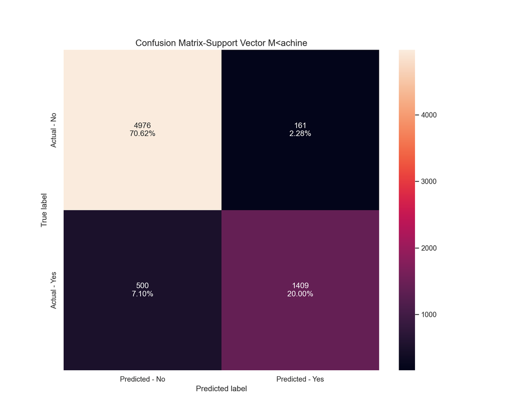

```python
cm_svc = metrics.confusion_matrix(y_test_np, y_predBase_svc, labels=[0,1])
df_cm_svc = pd.DataFrame(cm_svc, index=["Actual - No", "Actual - Yes"], columns=["Predicted - No", "Predicted - Yes"])
group_counts = ["{0:0.0f}".format(value) for value in cm_svc.flatten()]
group_percentages = ["{0:.2%}".format(value) for value in cm_svc.flatten()/np.sum(cm_svc)]
labels = [f"{v1}\n{v2}" for v1, v2 in zip(group_counts, group_percentages)]
labels = np.asarray(labels).reshape(2,2)

plt.figure(figsize=(11,9))
sns.heatmap(df_cm_svc, annot=labels, fmt='')
plt.ylabel('True label')
plt.xlabel('Predicted label')

plt.title("Confusion Matrix-Support Vector M<achine", fontsize=14)

plt.show()
```

```python
plt.clf()
```

Our SVC classifier performed better on accurately predicting fraud of yes (20%) than the logistic regression classfier (13.84%). Additionaly, the svc classifier inaccurate fraud predictions of yes was only 2.28% compated to the logistic regression model’s 7.41%

## Random Forest

Random forest is an ensemble learning method. Ensemble learning takes predictions from multiple models are merges them to enhance the accuracy of prediction. There are four types of ensemble techniques. We’ll be using Bagging (which random forest is an example of) and boosting, which our next four models will be an example of.

Bagging involves fitting many decision trees on different samples of the same dataset and averaging the predictions.

Random Forest models are made up of individual decision trees whose predictions are combined for a final result. The final result is decided using majority rules which means that the final prediction is what the majority of the decision tree models chose. An example would be 5 models in which 3 of the 5 models predict ‘yes’ for the classification problem.

Random Forests can be made up of thousands of decision trees.

Simply put, the random forest builds multiple decision trees and merges them together to get a more accurate prediction.

[Random Forest for Beginners](https://www.analyticsvidhya.com/blog/2021/10/an-introduction-to-random-forest-algorithm-for-beginners/)

```python
from sklearn.ensemble import RandomForestClassifier
```

### Base Model

```python
rf=RandomForestClassifier(random_state=1,n_jobs=-1)
```

```python
rf_base_clf=rf.fit(X_train_tr, y_train_np)
```

```python
start_time = time.time()
rf_base_cv_accuracy=cross_val_score(rf_base_clf, X_train_tr, y_train_np, cv=skf, scoring='accuracy').mean().round(2)
rfBase_CrossValAccur = time.time() - start_time
```

```python
start_time = time.time()
rf_base_cv_recall=cross_val_score(rf_base_clf, X_train_tr, y_train_np, cv=skf, scoring='recall').mean().round(2)
rfBase_CrossValRecall = time.time() - start_time
```

```python
start_time = time.time()
rf_base_cv_precision=cross_val_score(rf_base_clf, X_train_tr, y_train_np, cv=skf, scoring='precision').mean().round(2)
rfBase_CrossValPrec = time.time() - start_time
```

```python
start_time = time.time()
rf_base_cv_f1=cross_val_score(rf_base_clf, X_train_tr, y_train_np, cv=skf, scoring='f1').mean().round(2)
rfBase_CrossValF1 = time.time() - start_time
```

```python
start_time = time.time()
rf_base_cv_auc=cross_val_score(rf_base_clf, X_train_tr, y_train_np, cv=skf, scoring=roc_auc_scorer).mean().round(2)
rfBase_CrossValAuc = time.time() - start_time
```

### Crossvalidation with parameters

```python
rf_params={'n_estimators':[500,1000,22500,5000],
'max_features':[0.25,0.50,0.75,1.0],
'min_samples_split':[2,4,6,8],
#'max_depth': [500, 1000, 2000, 4000,6000],
'max_depth': list(range(500,15000,500)),
'min_samples_leaf': [3, 4, 5, 6],
'criterion': ['gini', 'entropy', 'log_loss']}
```

```python
rf_search=RandomizedSearchCV(rf, rf_params, n_iter=6,refit=True,
verbose=3,cv=5, scoring='roc_auc',return_train_score=True, n_jobs=-1)
```

```python
start_time = time.time()
rf_search.fit(X_train_tr, y_train_np)
```

```
RandomizedSearchCV(cv=5,
                   estimator=RandomForestClassifier(n_jobs=-1, random_state=1),
                   n_iter=6, n_jobs=-1,
                   param_distributions={'criterion': ['gini', 'entropy',
                                                      'log_loss'],
                                        'max_depth': [500, 1000, 1500, 2000,
                                                      2500, 3000, 3500, 4000,
                                                      4500, 5000, 5500, 6000,
                                                      6500, 7000, 7500, 8000,
                                                      8500, 9000, 9500, 10000,
                                                      10500, 11000, 11500,
                                                      12000, 12500, 13000,
                                                      13500, 14000, 14500],
                                        'max_features': [0.25, 0.5, 0.75, 1.0],
                                        'min_samples_leaf': [3, 4, 5, 6],
                                        'min_samples_split': [2, 4, 6, 8],
                                        'n_estimators': [500, 1000, 22500,
                                                         5000]},
                   return_train_score=True, scoring='roc_auc', verbose=3)
```

```python
rf_grid_training_time = time.time() - start_time
```

```python
rf_cv_results=pd.DataFrame(rf_search.cv_results_)
```

```python
rf_cv_results[['mean_train_score', 'std_train_score','mean_test_score', 'std_test_score']].mean()
```

```
## mean_train_score    0.993862
## std_train_score     0.000114
## mean_test_score     0.905631
## std_test_score      0.005357
## dtype: float64
```

Cross validation mean score for train is .09 higher than the mean test score. This could be a case of overfitting. Applying the classifier to test data will provide more metrics to help us.

```
RandomForestClassifier(criterion='entropy', max_depth=14500, max_features=0.5,
                       min_samples_leaf=3, min_samples_split=6,
                       n_estimators=500, n_jobs=-1, random_state=1)
```

The above display presents the parameters chosen for the random Forest classifier.

```python
start_time = time.time()
rf_cv_accuracy=cross_val_score(rf_clf, X_train_tr, y_train_np,
scoring='accuracy', cv=skf, n_jobs=-1).mean().round(2)
rf_CrossAccur_time = time.time() - start_time
```

```python
start_time = time.time()
rf_cv_recall=cross_val_score(rf_clf, X_train_tr, y_train_np,
scoring=recall_scorer,cv=skf, n_jobs=-1).mean().round(2)
rf_CrossValRecall_time = time.time() - start_time
```

```python
start_time = time.time()
rf_cv_precision=cross_val_score(rf_clf, X_train_tr, y_train_np,
scoring=precision_scorer, cv=skf, n_jobs=-1).mean().round(2)
rf_CrossValPrec_time = time.time() - start_time
```

```python
start_time = time.time()
rf_cv_f1=cross_val_score(rf_clf, X_train_tr, y_train_np,
scoring='f1', cv=skf, n_jobs=-1).mean().round(2)
rf_CrossValF1_time = time.time() - start_time
```

```python
start_time = time.time()
rf_cv_auc=cross_val_score(rf_clf, X_train_tr, y_train_np,
scoring=roc_auc_scorer, cv=skf, n_jobs=-1).mean().round(2)
rf_CrossValAuc_time = time.time() - start_time
```

### Test Set

We’ll now use the classifier to predict on the test data.

```python
y_pred_Base_rf=rf_base_clf.predict(X_test_tr)
```

```
## *******Random Forest Classification Report********
```

```
##               precision    recall  f1-score   support
##
##            0       0.91      0.97      0.94      5137
##            1       0.91      0.73      0.81      1909
##
##     accuracy                           0.91      7046
##    macro avg       0.91      0.85      0.87      7046
## weighted avg       0.91      0.91      0.90      7046
```

```python
rfBase_recall_test=recall_score(y_test_np, y_pred_Base_rf, pos_label=1).round(2)
```

```python
rfBase_roc_test=roc_auc_score(y_test_np, y_pred_Base_rf).round(2)
```

```python
rfBase_precision_test=precision_score(y_test_np, y_pred_Base_rf, pos_label=1).round(2)
```

```python
rfBase_test_accuracy=accuracy_score(y_test_np, y_pred_Base_rf).round(2)
```

```python
rfBase_test_f1=f1_score(y_test_np, y_pred_Base_rf).round(2)
```

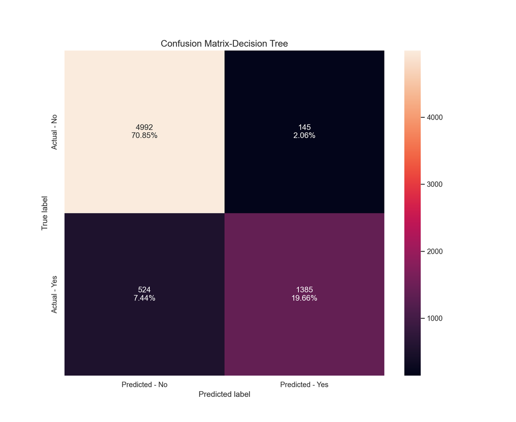

```python
cm_rf_vl = metrics.confusion_matrix(y_test_np, y_pred_Base_rf, labels=[0,1])
df_cm_rf_vl = pd.DataFrame(cm_rf_vl, index=["Actual - No", "Actual - Yes"], columns=["Predicted - No", "Predicted - Yes"])
group_counts = ["{0:0.0f}".format(value) for value in cm_rf_vl.flatten()]
group_percentages = ["{0:.2%}".format(value) for value in cm_rf_vl.flatten()/np.sum(cm_rf_vl)]
labels = [f"{v1}\n{v2}" for v1, v2 in zip(group_counts, group_percentages)]
labels = np.asarray(labels).reshape(2,2)

plt.figure(figsize=(11,9))
sns.heatmap(df_cm_rf_vl, annot=labels, fmt='')
plt.ylabel('True label')
plt.xlabel('Predicted label')

plt.title("Confusion Matrix-Decision Tree", fontsize=14)

plt.show()
```

```python
plt.clf()
```

The performance of our random forest classifier at accurately predicting fraud of Yes is 19.66%, only slightly less than the SVC’s 20%. Random Forest did have a slightly lower percentage of inaccurately predicing fraud of yes (2.06%)

### Feature Importance

```python
# let's create a dictionary of features and their importance values
feat_dict_rf= {}
for col, val in sorted(zip(X_train_tr.columns, rf_base_clf.feature_importances_),key=lambda x:x[1],reverse=True):
  feat_dict_rf[col]=val
```

```python
feat_rf_df = pd.DataFrame({'Feature':feat_dict_rf.keys(),'Importance':feat_dict_rf.values()})
```

```python
feat_rf_tp5=feat_rf_df.nlargest(5,"Importance")
```

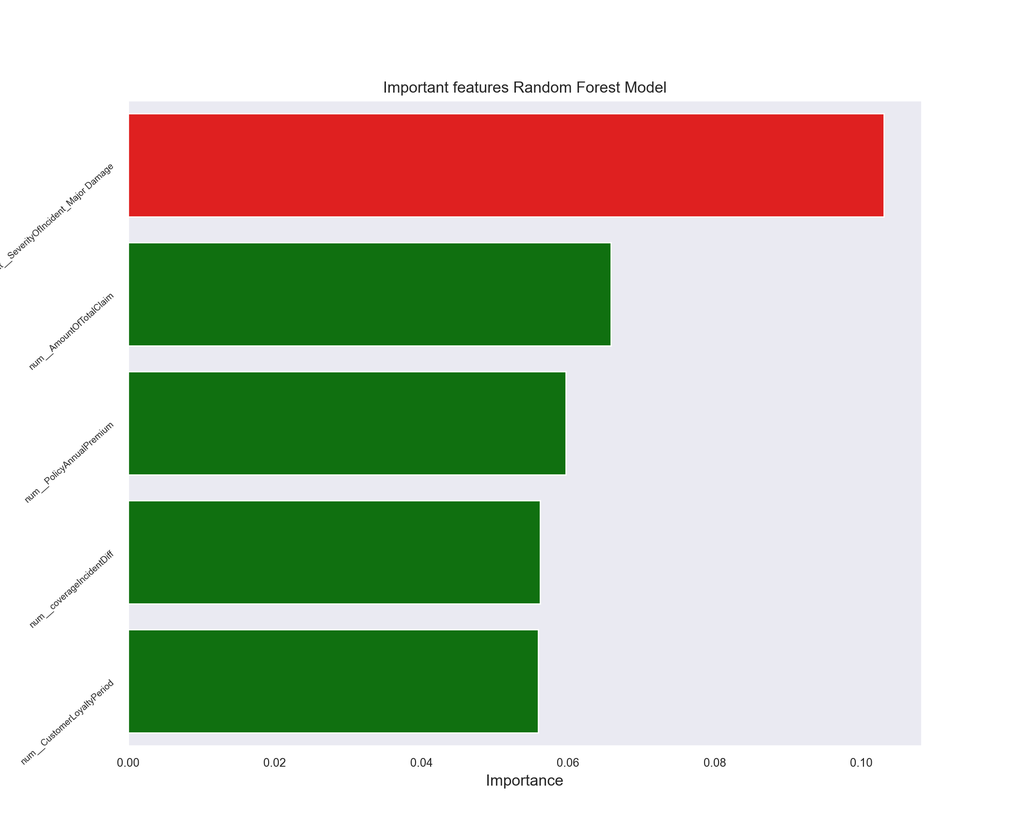

```python
values = feat_rf_tp5.Importance
idx = feat_rf_tp5.Feature
plt.figure(figsize=(11,9))
clrs = ['green' if (x < max(values)) else 'red' for x in values ]
sns.barplot(y=idx,x=values,palette=clrs).set(title='Important features Random Forest Model')

plt.ylabel("Features", fontsize=510)

plt.tick_params(axis='x', which='major', labelsize=9)

plt.tick_params(axis='y', labelsize=7,labelrotation=42)

plt.show()
```

```python
plt.clf()
```

Of the top features for our random forest model, it’s interesting to note that two through five are also important features of our anomaly detection model.

## Gradient Boosting

The main idea behind this algorithm is to build models sequentially and these subsequent models try to reduce the errors of the previous model. Errors are reduced by building a new model on the errors or residuals of the previous model.

```python
from sklearn.ensemble import GradientBoostingClassifier
```

### Base Model

```python
gb_base_clf=gb.fit(X_train_tr, y_train_np)
```

```python
start_time = time.time()
gb_base_cv_accuracy=cross_val_score(gb_base_clf, X_train_tr, y_train_np, cv=skf, scoring='accuracy').mean().round(2)
gbBase_CrossValAccur = time.time() - start_time
```

```python
start_time = time.time()
gb_base_cv_recall=cross_val_score(gb_base_clf, X_train_tr, y_train_np, cv=skf, scoring=recall_scorer).mean().round(2)
gbBase_CrossValRecall= time.time() - start_time
```

```python
start_time = time.time()
gb_base_cv_precision=cross_val_score(gb_base_clf, X_train_tr, y_train_np, cv=skf, scoring=precision_scorer).mean().round(2)
gbBase_CrossValPrec = time.time() - start_time
```

```python
start_time = time.time()
gb_base_cv_f1=cross_val_score(gb_base_clf, X_train_tr, y_train_np, cv=skf, scoring='f1').mean().round(2)
gbBase_CrossValF1 = time.time() - start_time
```

```python
start_time = time.time()
gb_base_cv_auc=cross_val_score(gb_base_clf, X_train_tr, y_train_np, cv=skf, scoring=roc_auc_scorer).mean().round(2)
gbBase_CrossValAuc = time.time() - start_time
```

### Cross Validcation with parameters

```python
gb_params={
  'subsample':[0.4, 0.6, 0.7, 0.75],
  'n_estimators':np.arange(500, 10000, 500),
  'learning_rate':[0.0001, 0.001,.01,0.05, 0.075,0.1],
  'max_features':range(6,20,2),
  'min_samples_split':range(1000,2200,200),
  'min_samples_leaf':range(30,70,10),
  'max_depth':range(4,16,2),

}
```

```python
search_cv_gb=RandomizedSearchCV(estimator=gb,param_distributions=gb_params,n_iter=6, scoring='roc_auc', cv=5, verbose=1, refit=True,return_train_score=True, n_jobs=-1, random_state=2)
```

```python
start_time = time.time()
search_cv_gb.fit(X_train_tr, y_train_np)
```

```
RandomizedSearchCV(cv=5, estimator=GradientBoostingClassifier(warm_start=True),
                   n_iter=6, n_jobs=-1,
                   param_distributions={'learning_rate': [0.0001, 0.001, 0.01,
                                                          0.05, 0.075, 0.1],
                                        'max_depth': range(4, 16, 2),
                                        'max_features': range(6, 20, 2),
                                        'min_samples_leaf': range(30, 70, 10),
                                        'min_samples_split': range(1000, 2200, 200),
                                        'n_estimators': array([ 500, 1000, 1500, 2000, 2500, 3000, 3500, 4000, 4500, 5000, 5500,
       6000, 6500, 7000, 7500, 8000, 8500, 9000, 9500]),
                                        'subsample': [0.4, 0.6, 0.7, 0.75]},
                   random_state=2, return_train_score=True, scoring='roc_auc',
                   verbose=1)
```

```python
gb_grid_training_time = time.time() - start_time
```

```python
gb_cv_results=pd.DataFrame(search_cv_gb.cv_results_)
```

```python
gb_cv_results[['mean_train_score', 'std_train_score','mean_test_score', 'std_test_score']].mean()
```

```
## mean_train_score    0.933659
## std_train_score     0.000696
## mean_test_score     0.881175
## std_test_score      0.006381
## dtype: float64
```

Cross validation mean score for train is .05 higher than the mean test score. This could be a case of overfitting. Applying the classifier to test data will provide more metrics to help us.

```python
gb_clf=search_cv_gb.best_estimator_
```

```python
gb_clf
```

```
GradientBoostingClassifier(max_depth=12, max_features=10, min_samples_leaf=30,
                           min_samples_split=1000, n_estimators=3000,
                           subsample=0.7, warm_start=True)
```

The above display presents the parameters chosen for the gradient boost model.

```python
start_time = time.time()
gb_cv_f1_score=cross_val_score(gb_clf, X_train_tr, y_train_np,
scoring='f1', cv=skf, n_jobs=-1).mean().round(2)
gb_CrossValF1_time = time.time() - start_time
```

```python
start_time = time.time()
gb_cv_accuracy=cross_val_score(gb_clf, X_train_tr, y_train_np,
scoring='accuracy', cv=skf, n_jobs=-1).mean().round(2)
gb_CrossValAccur_time = time.time() - start_time
```

```python
start_time = time.time()
gb_cv_recall=cross_val_score(gb_clf, X_train_tr, y_train_np,
scoring=recall_scorer, cv=skf, n_jobs=-1).mean().round(2)
gb_CrossValRecall_time = time.time() - start_time
```

```python
start_time = time.time()
gb_cv_precision=cross_val_score(gb_clf, X_train_tr, y_train_np,
scoring=precision_scorer, cv=skf, n_jobs=-1).mean().round(2)
gb_CrossValPrec_time = time.time() - start_time
```

```python
start_time = time.time()
gb_cv_auc=cross_val_score(gb_clf, X_train_tr, y_train_np,
scoring=roc_auc_scorer, cv=skf, n_jobs=-1).mean().round(2)
gb_CrossValAuc_time = time.time() - start_time
```

### Metrics and Feature Importance

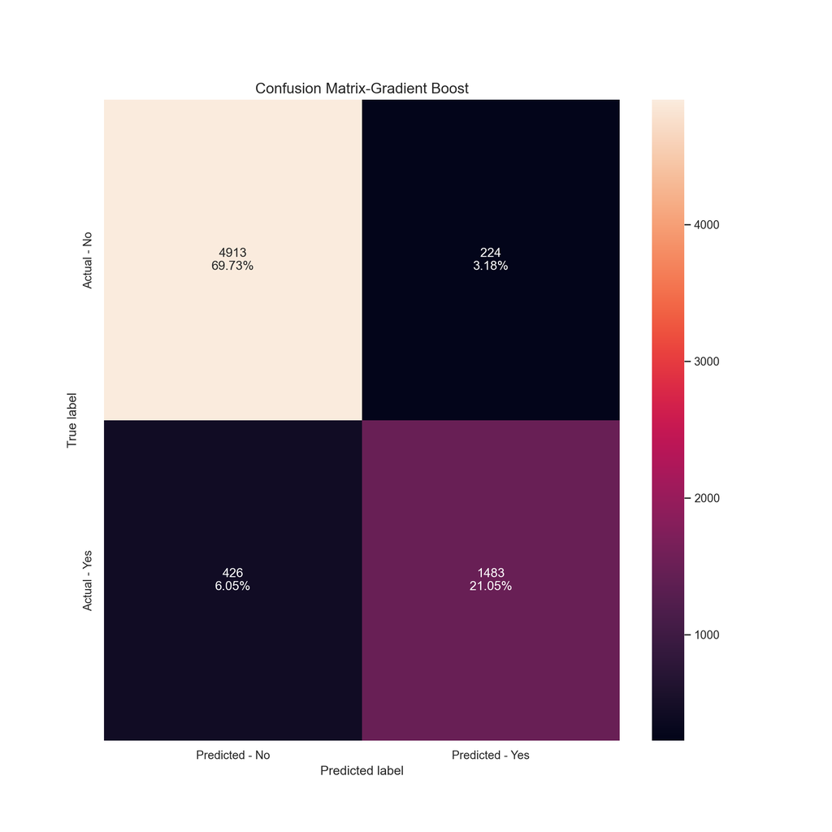

```python
cm_gb_vl = metrics.confusion_matrix(y_test_np, y_pred_gb, labels=[0,1])
df_cm_gb_vl = pd.DataFrame(cm_gb_vl, index=["Actual - No", "Actual - Yes"], columns=["Predicted - No", "Predicted - Yes"])
group_counts = ["{0:0.0f}".format(value) for value in cm_gb_vl.flatten()]
group_percentages = ["{0:.2%}".format(value) for value in cm_gb_vl.flatten()/np.sum(cm_gb_vl)]
labels = [f"{v1}\n{v2}" for v1, v2 in zip(group_counts, group_percentages)]
labels = np.asarray(labels).reshape(2,2)

plt.figure(figsize=(11,11))
sns.heatmap(df_cm_gb_vl, annot=labels, fmt='')
plt.ylabel('True label')
plt.xlabel('Predicted label')


plt.title("Confusion Matrix-Gradient Boost", fontsize=14)

plt.show()
```

```python
plt.clf()
```

The performance of our gradient boost classifier at accurately predicting fraud of Yes is 21.05%, which is just above the random Forest’s 19.66%, only and SVC’s 20%. However, gradient boost’s inaccurate predictions of fraud of yes is 3.18%, 1% more than the other two classifiers.

```python
#  create a dictionary of features and their importance values
feat_dict_gb = {}
for col, val in sorted(zip(X_train_tr.columns,gb_clf.feature_importances_),key=lambda x:x[1],reverse=True):
  feat_dict_gb[col]=val
```

```python
feat_gb_df= pd.DataFrame({'Feature':feat_dict_gb.keys(),'Importance':feat_dict_gb.values()})
```

```python
feat_gb_tp5=feat_gb_df.nlargest(5,"Importance")
```

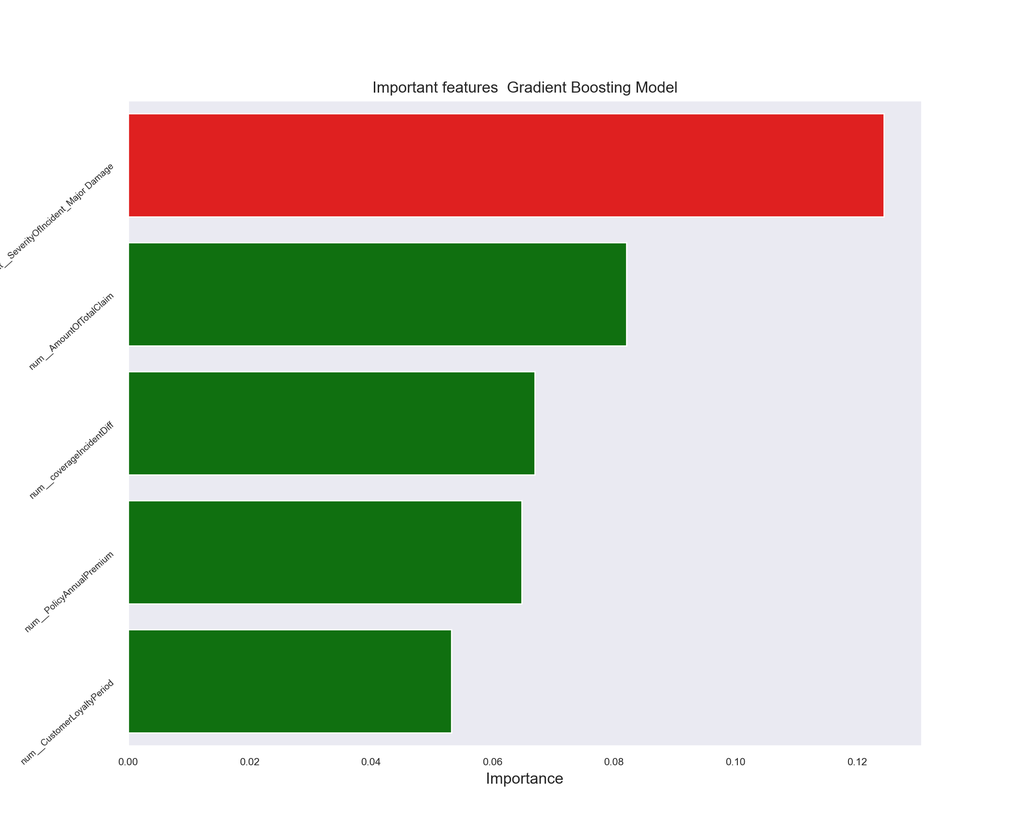

```python
values = feat_gb_tp5.Importance
idx = feat_gb_tp5.Feature
plt.figure(figsize=(11,9))
clrs = ['green' if (x < max(values)) else 'red' for x in values ]
sns.barplot(y=idx,x=values,palette=clrs).set(title='Important features  Gradient Boosting Model')

plt.ylabel("Features", fontsize=8)

plt.tick_params(axis='x', which='major', labelsize=8)

plt.tick_params(axis='y', labelsize=7, labelrotation=42)

plt.show()
```

```python
plt.clf()
```

The top features of our gradient boost model are the same as those from the random forest model

## Extreme Gradient Boosting

Extreme Gradient boosting is similar to gradient boosting with a few improvements. First, enhancements make it faster than other ensemble methods. Secondly, built-in regularization allows it to have an advantage in accuracy. Regularization is the process of adding information to reduce variance and prevent over fitting.

```python
from xgboost import XGBClassifier
```

### Base Model

```python
xgb=XGBClassifier(booster='gbtree',objective='binary:logistic', n_jobs=-1)
```

```python
xgb_base_clf=xgb.fit(X_train_tr, y_train_np)
```

```python
start_time = time.time()


xgb_base_cv_accuracy=cross_val_score(xgb_base_clf, X_train_tr, y_train_np, cv=skf, scoring='accuracy').mean().round(2)
xgbBase_CrossValAccur = time.time() - start_time
```

```python
start_time = time.time()
xgb_base_cv_recall=cross_val_score(xgb_base_clf, X_train_tr, y_train_np, cv=skf, scoring=recall_scorer).mean().round(2)
xgbBase_CrossValRecall = time.time() - start_time
```

```python
start_time = time.time()
xgb_base_cv_precision=cross_val_score(xgb_base_clf, X_train_tr, y_train_np, cv=skf, scoring=precision_scorer).mean().round(2)
xgbBase_CrossValPrec = time.time() - start_time
```

```python
start_time = time.time()
xgb_base_cv_f1=cross_val_score(xgb_base_clf, X_train_tr, y_train_np, cv=skf, scoring='f1').mean().round(2)
xgbBase_CrossValF1 = time.time() - start_time
```

```python
start_time = time.time()
xgb_base_cv_auc=cross_val_score(xgb_base_clf, X_train_tr, y_train_np, cv=skf, scoring=roc_auc_scorer).mean().round(2)
xgbBase_CrossValAuc = time.time() - start_time
```

### Cross Validcation with Parameters

```python
params_xg={
    "learning_rate": [0.01, 0.05, 0.10, 0.20,0.25,0.4, 0.5],
    "max_depth": range(2,10,2),
    "min_child_weight": [1,3,5,7],
    "gamma": [0.0,0.01,0.05,0.1,0.5,1,2,3],
    "colsample_bytree": [0.5,0.6,0.7,0.8,0.9,1],
    "colsample_bynode": [0.5,0.6,0.7,0.8,0.9,1],
    "colsample_bylevel": [0.5,0.6,0.7,0.8,0.9,1],
    "n_estimators":np.arange(500, 4000, 500),
    'subsample': [0.5,0.6,0.7,0.8,0.9,1]




}
```

```python
search_xg=RandomizedSearchCV(estimator=xgb,
param_distributions=params_xg,n_iter=6, scoring='roc_auc', cv=5, verbose=3, refit=True,return_train_score=True, n_jobs=-1)
```

```python
start_time = time.time()
search_xg.fit(X_train_tr, y_train_np)
```

```
RandomizedSearchCV(cv=5,
                   estimator=XGBClassifier(base_score=None, booster='gbtree',
                                           callbacks=None,
                                           colsample_bylevel=None,
                                           colsample_bynode=None,
                                           colsample_bytree=None,
                                           early_stopping_rounds=None,
                                           enable_categorical=False,
                                           eval_metric=None, feature_types=None,
                                           gamma=None, gpu_id=None,
                                           grow_policy=None,
                                           importance_type=None,
                                           interaction_constraints=None,
                                           learning_...
                                        'colsample_bynode': [0.5, 0.6, 0.7, 0.8,
                                                             0.9, 1],
                                        'colsample_bytree': [0.5, 0.6, 0.7, 0.8,
                                                             0.9, 1],
                                        'gamma': [0.0, 0.01, 0.05, 0.1, 0.5, 1,
                                                  2, 3],
                                        'learning_rate': [0.01, 0.05, 0.1, 0.2,
                                                          0.25, 0.4, 0.5],
                                        'max_depth': range(2, 10, 2),
                                        'min_child_weight': [1, 3, 5, 7],
                                        'n_estimators': array([ 500, 1000, 1500, 2000, 2500, 3000, 3500]),
                                        'subsample': [0.5, 0.6, 0.7, 0.8, 0.9,
                                                      1]},
                   return_train_score=True, scoring='roc_auc', verbose=3)
```

```python
xgb_grid_training_time = time.time() - start_time
```

```python
xgb_cv_results=pd.DataFrame(search_xg.cv_results_)
```

```python
xgb_cv_results[['mean_train_score', 'std_train_score','mean_test_score', 'std_test_score']].mean()
```

```
## mean_train_score    0.984471
## std_train_score     0.000194
## mean_test_score     0.902756
## std_test_score      0.006329
## dtype: float64
```

Cross validation mean score for train is .08 higher than the mean test score. This could be a case of overfitting. Applying the classifier to test data will provide more metrics to help us.

```python
xg_clf=search_xg.best_estimator_
```

```
XGBClassifier(base_score=None, booster='gbtree', callbacks=None,
              colsample_bylevel=0.7, colsample_bynode=1, colsample_bytree=0.6,
              early_stopping_rounds=None, enable_categorical=False,
              eval_metric=None, feature_types=None, gamma=0.01, gpu_id=None,
              grow_policy=None, importance_type=None,
              interaction_constraints=None, learning_rate=0.01, max_bin=None,
              max_cat_threshold=None, max_cat_to_onehot=None,
              max_delta_step=None, max_depth=8, max_leaves=None,
              min_child_weight=1, missing=nan, monotone_constraints=None,
              n_estimators=1500, n_jobs=-1, num_parallel_tree=None,
              predictor=None, random_state=None, ...)
```

```python
start_time = time.time()
xg_cv_accuracy=cross_val_score(xg_clf, X_train_tr, y_train_np,
scoring='accuracy', cv=skf, n_jobs=-1).mean().round(2)

xgb_CrossValAccur_time = time.time() - start_time
```

```python
start_time = time.time()
xg_cv_recall=cross_val_score(xg_clf, X_train_tr, y_train_np,
scoring=recall_scorer, cv=skf, n_jobs=-1).mean().round(2)
xgb_CrossValRecall_time = time.time() - start_time
```

```python
start_time = time.time()
xg_cv_precision=cross_val_score(xg_clf, X_train_tr, y_train_np,
scoring=precision_scorer, cv=skf, n_jobs=-1).mean().round(2)
xgb_CrossValPrec_time = time.time() - start_time
```

```python
start_time = time.time()
xg_cv_auc=cross_val_score(xg_clf, X_train_tr, y_train_np,
scoring=roc_auc_scorer, cv=skf, n_jobs=-1).mean().round(2)
xgb_CrossValAuc_time = time.time() - start_time
```

```python
start_time = time.time()
xg_cv_f1=cross_val_score(xg_clf, X_train_tr, y_train_np,
scoring='f1', cv=skf, n_jobs=-1).mean().round(2)
xgb_CrossValF1_time = time.time() - start_time
```

### Test Set

```python
y_test_pred_base_xg=xgb_base_clf.predict(X_test_tr)
```

```
## *******Extreme Gradient Boost Classification Report********
```

```
##               precision    recall  f1-score   support
##
##            0       0.91      0.97      0.94      5137
##            1       0.89      0.74      0.81      1909
##
##     accuracy                           0.91      7046
##    macro avg       0.90      0.86      0.88      7046
## weighted avg       0.91      0.91      0.90      7046
```

```python
xg_recall_test_base=recall_score(y_test_np, y_test_pred_base_xg).round(2)
```

```python
xg_roc_test_base=roc_auc_score(y_test_np, y_test_pred_base_xg).round(2)
```

```python
xg_test_accuracy_base=accuracy_score(y_test_np, y_test_pred_base_xg).round(2)
```

```python
xg_test_f1_base=f1_score(y_test_np, y_test_pred_base_xg).round(2)
```

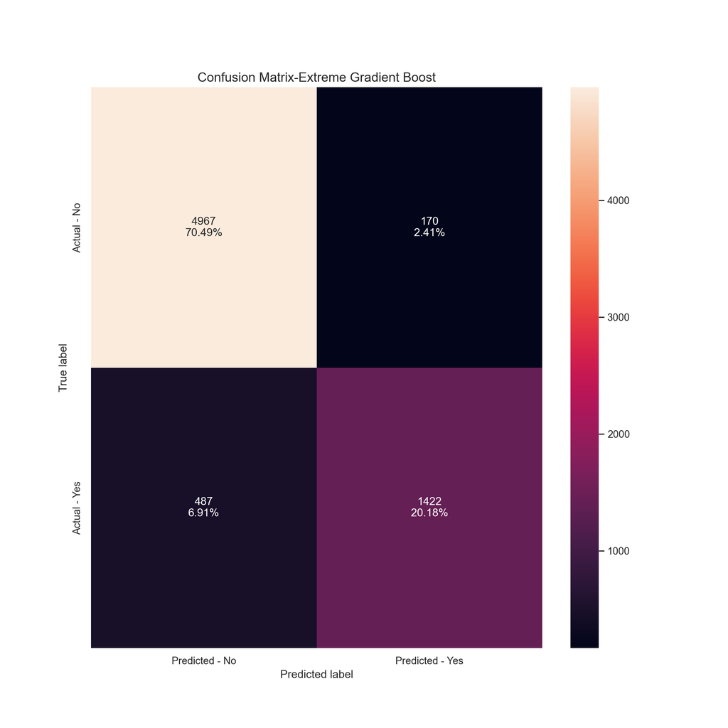

```python
cm_xg_vl = metrics.confusion_matrix(y_test_np, y_test_pred_base_xg, labels=[0,1])
df_cm_xg_vl = pd.DataFrame(cm_xg_vl, index=["Actual - No", "Actual - Yes"], columns=["Predicted - No", "Predicted - Yes"])
group_counts = ["{0:0.0f}".format(value) for value in cm_xg_vl.flatten()]
group_percentages = ["{0:.2%}".format(value) for value in cm_xg_vl.flatten()/np.sum(cm_xg_vl)]
labels = [f"{v1}\n{v2}" for v1, v2 in zip(group_counts, group_percentages)]
labels = np.asarray(labels).reshape(2,2)

plt.figure(figsize=(11,11))
sns.heatmap(df_cm_xg_vl, annot=labels, fmt='')
plt.ylabel('True label')
plt.xlabel('Predicted label')


plt.title("Confusion Matrix-Extreme Gradient Boost", fontsize=14)

plt.show()
```

```python
plt.clf()
```

The extreme gradient classifier’s accurate and inaccurate predictions of fraud Yes are close to both random forest and svc classifiers at 20.18% and 2.41%. respectively.

### Feature Importance

```python
# let's create a dictionary of features and their importance values
feat_dict_xg= {}
for col, val in sorted(zip(X_train_tr.columns,xgb_base_clf.feature_importances_),key=lambda x:x[1],reverse=True):
  feat_dict_xg[col]=val
```

```python
feat_xg_df = pd.DataFrame({'Feature':feat_dict_xg.keys(),'Importance':feat_dict_xg.values()})
```

```python
feat_xg_tp5=feat_xg_df.nlargest(5,"Importance")
```

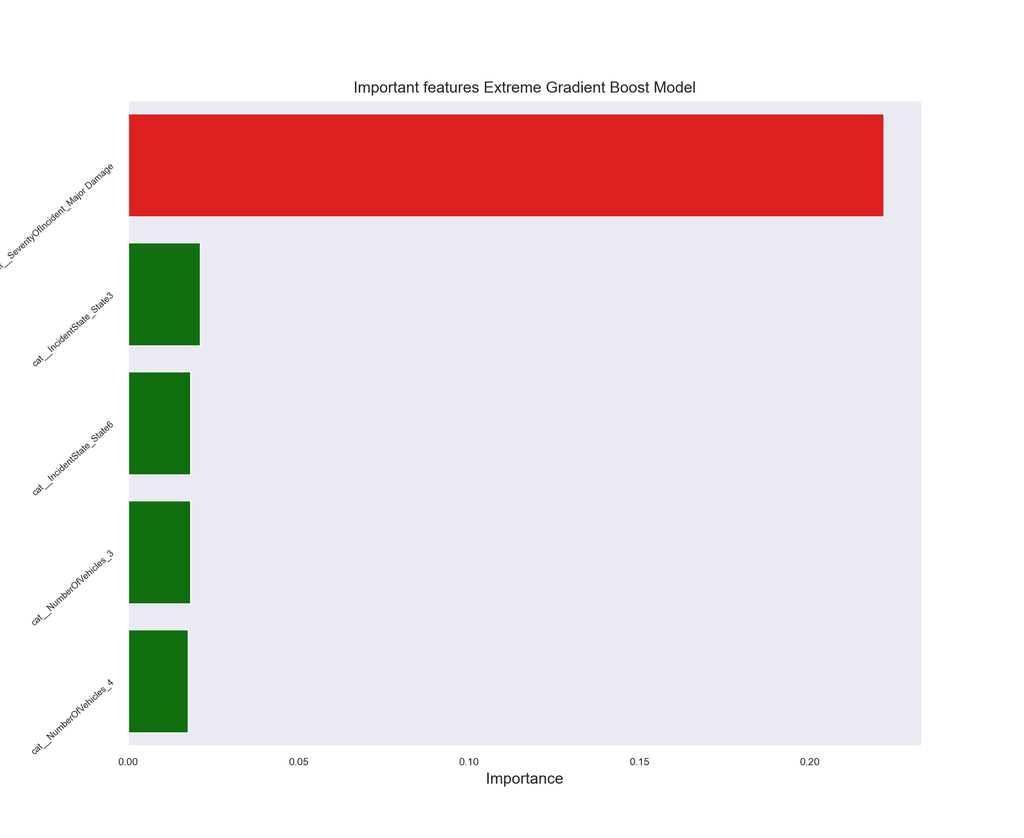

```python
values = feat_xg_tp5.Importance
idx = feat_xg_tp5.Feature
plt.figure(figsize=(11,9))
clrs = ['green' if (x < max(values)) else 'red' for x in values ]
sns.barplot(y=idx,x=values,palette=clrs).set(title='Important features Extreme Gradient Boost Model')

plt.ylabel("Features", fontsize=9)

plt.tick_params(axis='x', which='major', labelsize=8)

plt.tick_params(axis='y', labelsize=7, labelrotation=42)

plt.show()
```

```python
plt.clf()
```

Extreme Gradient Boost’s highest scoring important feature of severity of incident level Major Damage the same as gradient boost. The difference is it’s score of 20% dominates compared to the other important features scores which hover around 2%.

## Model Comparison

```python
metric_comparison=pd.DataFrame({'Model':['Logistic Regresion','Support Vector Machine', 'Random Forest', 'Gradient Boosting', 'Extreme Gradient Boosting'],
'RecallBase':[lr_base_cv_recall_score, svc_base_cv_recall,rf_base_cv_recall, gb_base_cv_recall, xgb_base_cv_recall],
'RecallTune':[lr_cv_recall_score, svc_cv_recall_score,rf_cv_recall, gb_cv_recall, xg_cv_recall],
'PrecisionBase':[lr_base_cv_precision_score, svc_base_cv_precision,rf_base_cv_precision, gb_base_cv_precision, xgb_base_cv_precision],
'PrecisionTune':[lr_cv_precision_score, svc_cv_precision,rf_cv_precision, gb_cv_precision, xg_cv_precision],
'F1Base':[lr_base_cv_f1,svc_base_cv_f1, rf_base_cv_f1,gb_base_cv_f1, xgb_base_cv_f1],
'F1Tune':[lr_cv_f1_score, svc_cv_f1_score,rf_cv_f1, gb_cv_f1_score, xg_cv_f1],
'AUCBase':[lr_base_cv_auc_score, svc_base_cv_auc_score,rf_base_cv_auc, gb_base_cv_auc, xgb_base_cv_auc],
'AUCTune':[lr_cv_auc_score, svc_cv_auc, rf_cv_auc, gb_cv_auc,xg_cv_auc],
'GridTuneTime':[log_grid_training_time, svc_grid_training_time, rf_grid_training_time, gb_grid_training_time,xgb_grid_training_time],
'CVTime':[log_cross_val_Time, svc_cross_val_Time, rf_cross_val_Time, gb_cross_val_Time, xgb_cross_val_Time],
'CVBaseTime':[log_cross_valBase_Time,svcBase_cross_val_Time, rfBase_cross_val_Time,gbBase_cross_val_Time,xgbBase_cross_val_Time]})
```

```python
metricTest_comparison=pd.DataFrame({'Model':['Support Vector Machine', 'Random Forest',  'Extreme Gradient Boosting'],
'RecallBase':[svc_base_cv_recall,rf_base_cv_recall, xgb_base_cv_recall],
'RecallTest':[svc_recallBase_test,rfBase_recall_test, xg_recall_test_base],
'PrecisionBase':[svc_base_cv_precision,rf_base_cv_precision, xgb_base_cv_precision],
'PrecisionTest':[svcBase_precision_test,rfBase_precision_test, xg_test_precision_base],
'F1Base':[svc_base_cv_f1, rf_base_cv_f1,xgb_base_cv_f1],
'F1Test':[svc_f1Base_test,rfBase_test_f1, xg_test_f1_base],
'AUCBase':[svc_base_cv_auc_score,rf_base_cv_auc, xgb_base_cv_auc],
'AUCTest':[svc_aucBase_test, rfBase_roc_test,xg_roc_test_base]

})
```

```python
metric_comparison=metric_comparison.round({'RecallCVbase':2,'RecallCVgridSearch':2,'PrecisionCVbase':2,
'PrecisionCVgridSearch':2,'F1CVbase':2,'F1CVgridSearch':2,'AUCcvBase':2, 'AUCcvGridSearch':2,'GridTuneTime':2, 'CVTime':2, 'CVBaseTime':2})
```

```r
library(dplyr)
library(gt)
library(gtExtras)
library(ggsci)
library(RColorBrewer)
library(ggplot2)
library(readr)
```

```r
gt_comp_tbl <-
  gt(metric_comparison) %>%
  tab_header(
    title = md("**Model Cross Validation Comparison**"),
    subtitle = "Evaluation and Performance Metrics"
  ) %>%
  tab_spanner(
    label = "Metrics",
    columns = c(RecallBase, RecallTune , PrecisionBase,PrecisionTune,F1Base,F1Tune,AUCBase, AUCTune)
  ) %>%
  tab_spanner(
    label = "Time",
    columns = c(GridTuneTime,CVTime, CVBaseTime,CVTimeDiff )
  ) %>%
  tab_style(
    style=cell_text(size=px(10)),
    locations = cells_column_labels(c(Model,RecallBase, RecallTune , PrecisionBase,PrecisionTune,F1Base,F1Tune,AUCBase, AUCTune,GridTuneTime,CVTime, CVBaseTime, CVTimeDiff)
      )) %>%
  tab_style(
    style=cell_text(size=px(9.5)),
    locations = cells_body(c(RecallBase, RecallTune , PrecisionBase,PrecisionTune,F1Base,F1Tune,AUCBase, AUCTune,GridTuneTime,CVTime, CVBaseTime, CVTimeDiff))
  ) %>%
  tab_style(
    style = cell_text(size=px(10)),
    locations=cells_body(Model)
  ) %>%
  data_color(
    columns=c(PrecisionBase, PrecisionTune),
    method="numeric",
    palette="YlGn",
    domain=c(0.91,0.5)) %>%
  data_color(
    columns=c(RecallBase, RecallTune, F1Base, F1Tune, AUCBase, AUCTune),
    palette=c("#ffffff","#5A2D81"), domain=c(0.90,0.5)) %>%
  data_color(
    columns=c(GridTuneTime,CVTime,CVBaseTime, CVTimeDiff),
    palette=c("#ffffff","#FFC72C"), domain=c(231,-59)) %>%

  tab_options(table.background.color = "lightcyan") %>%
   tab_source_note(source_note = md("**Precsion, Recall, and F1 scores are displayed for prediction of 1 (Fraud=Yes)**")) %>%
  tab_style(
    style=cell_text(size=px(9)),
    locations=cells_source_notes()
  )
```

**Model Cross Validation Comparison**

Evaluation and Performance Metrics

| Model | Metrics RecallBase | Metrics RecallTune | Metrics PrecisionBase | Metrics PrecisionTune | Metrics F1Base | Metrics F1Tune | Metrics AUCBase | Metrics AUCTune | Time GridTuneTime | Time CVTime | Time CVBaseTime | Time CVTimeDiff |
| --- | --- | --- | --- | --- | --- | --- | --- | --- | --- | --- | --- | --- |
| Logistic Regresion | 0.51 | 0.51 | 0.65 | 0.65 | 0.57 | 0.57 | 0.70 | 0.70 | 1.46 | 0.66 | 1.78 | 1.12 |
| Support Vector Machine | 0.73 | 0.78 | 0.89 | 0.85 | 0.80 | 0.81 | 0.85 | 0.86 | 171.50 | 92.37 | 33.86 | -58.51 |
| Random Forest | 0.72 | 0.73 | 0.90 | 0.90 | 0.80 | 0.80 | 0.84 | 0.85 | 230.96 | 21.77 | 2.66 | -19.11 |
| Gradient Boosting | 0.55 | 0.77 | 0.74 | 0.87 | 0.63 | 0.82 | 0.74 | 0.87 | 135.59 | 42.59 | 41.63 | -0.96 |
| Extreme Gradient Boosting | 0.75 | 0.76 | 0.89 | 0.91 | 0.81 | 0.83 | 0.86 | 0.86 | 98.62 | 47.93 | 10.76 | -37.17 |

**Precsion, Recall, and F1 scores are displayed for prediction of 1 (Fraud=Yes)**

The table above presents evaluation metrics for class prediction of 1 (Yes), where the event of interest is a fraudulent submission. While all metrics are considered, Precision is our primary focus. A higher precision score indicates fewer false positives—cases where the model incorrectly flags a legitimate submission as fraudulent. Minimizing these errors is critical, as we do not want to falsely accuse a policyholder of fraud.

Recall, which reflects the rate of false negatives (predicting “No” when the actual class is “Yes”), is also important and will be the secondary metric of focus after precision.

Our next step is to compare these cross-validation results with those from the test set (unseen data). We will proceed with the three models that showed the best precision and training efficiency: SVM, Random Forest, and Extreme Gradient Boost.

```r
gt_Testcomp_tbl <-
  gt(metricTests_comparison) %>%
  tab_header(
    title = md("**Model Test/Cross Validationm Comparison**"),
    subtitle = "Evaluation Metrics"
  ) %>%
  tab_spanner(
    label = "Metrics",
    columns = c(RecallBase, RecallTest , PrecisionBase,PrecisionTest,F1Base,F1Test,AUCBase, AUCTest)
  ) %>%


  tab_style(
    style=cell_text(size=px(10)),
    locations = cells_column_labels(c(Model,RecallBase, RecallTest,PrecisionBase,PrecisionTest,F1Base,F1Test,AUCBase, AUCTest)
      )) %>%
  tab_style(
    style=cell_text(size=px(10)),
    locations=cells_body(c(RecallBase, RecallTest, PrecisionBase,PrecisionTest,F1Base,F1Test, AUCBase, AUCTest))
  ) %>%
  tab_style(
    style = cell_text(size=px(11)),
    locations=cells_body(Model)
  ) %>%
  data_color(
    columns=c(PrecisionBase,PrecisionTest),
    method="numeric",
    palette="Blues",
    domain=c(0.91,0.88)) %>%
  data_color(
    columns=c(RecallBase,  F1Base, AUCBase),
    palette=c("#ffffff","#5A2D81"), domain=c(0.86,0.71)) %>%
  data_color(
    columns=c( RecallTest, F1Test, AUCTest),
    palette=c("#ffffff","#FFC72C"), domain=c(0.86,0.71)) %>%

  tab_options(table.background.color = "lightcyan") %>%
  tab_source_note(source_note = md("**Precsion, Recall, and F1 scores are displayed for prediction of 1 (Fraud=Yes)**")) %>%
  tab_style(
    style=cell_text(size=px(9)),
    locations=cells_source_notes()
  ) %>%
  tab_style(
    style = cell_text(size=px(9)),
    locations = cells_column_spanners()
  )
```

**Model Test/Cross Validationm Comparison**

Evaluation Metrics

| Model | Metrics RecallBase | Metrics RecallTest | Metrics PrecisionBase | Metrics PrecisionTest | Metrics F1Base | Metrics F1Test | Metrics AUCBase | Metrics AUCTest | Difference in Cross Validation and Test Scores Recall_diff | Difference in Cross Validation and Test Scores Precision_diff | Difference in Cross Validation and Test Scores F1_diff | Difference in Cross Validation and Test Scores AUC_diff |
| --- | --- | --- | --- | --- | --- | --- | --- | --- | --- | --- | --- | --- |
| Support Vector Machine | 0.73 | 0.74 | 0.89 | 0.90 | 0.80 | 0.81 | 0.85 | 0.85 | -0.01 | -0.01 | -0.01 | 0.00 |
| Random Forest | 0.72 | 0.73 | 0.90 | 0.91 | 0.80 | 0.81 | 0.84 | 0.85 | -0.01 | -0.01 | -0.01 | -0.01 |
| Extreme Gradient Boosting | 0.75 | 0.74 | 0.89 | 0.89 | 0.81 | 0.81 | 0.86 | 0.86 | 0.01 | 0.00 | 0.00 | 0.00 |

**Precsion, Recall, and F1 scores are displayed for prediction of 1 (Fraud=Yes)**

The table above compares cross-validation scores with test set performance to evaluate how well our selected models generalize to unseen data. Specifically, we are looking for signs of overfitting or underfitting:

```
-Overfitting occurs when a model performs well on training data but poorly on new data—often indicated by training scores significantly higher than test scores.

-Underfitting happens when a model doesn’t learn the training data well, which can be suggested when
test scores are higher than training scores.
```

Examining other metrics:

[output not shown]

Given the strong overall performance and balance across metrics, Extreme Gradient Boost is selected as the final model for fitting to new data. However, Random Forest remains a strong alternative with it’s fast training time and may still be considered in further evaluations.

# New Data

Now that we have chosen a final model, we will use it to predict on new data. We will go through the same steps of cleaning, feature engineering, and preparation as with the original data.

The only difference between the new data and the data used for training and testing is that there are no labels, meaning that the observations have not been labled as fraud or no fraud.

We will validate that the columns of our newly imported data are equal to the columns of our originally imported data

```python
def df_columns_equal(df_original, df_new):
  assert df_original.columns.equals(df_new.columns), f"Mismatch in orginal data frame and new data frame columns"

  print("Orginal and new data frame columns match")
```

```python
df_columns_equal(Train_Demographics_p, new_Demographics)
```

```
## Orginal and new data frame columns match
```

```python
df_columns_equal(Train_Claim_p,new_Claim)
```

```
## Orginal and new data frame columns match
```

```python
df_columns_equal(Train_Policy_p,new_Policy)
```

```
## Orginal and new data frame columns match
```

We’ve confirmed that the columns of our new data sets are equal to the columns of our original data sets. We can now proceed to merge our new data sets.

```python
new_fraud=new_Claim.merge(new_Demographics, on="CustomerID")\
.merge(new_Policy, on="CustomerID")
```

Function to check if data is Data Frame

```python
def check_is_dataframe(df):
    assert isinstance(df, pd.DataFrame), f"Error: data is not Data Frame."
    print("Data is Data Frame")
```

```python
check_is_dataframe(new_fraud)
```

```
## Data is Data Frame
```

```
## Shape new_fraud: (8912, 37)
```

Our new data frame has 8,912 rows and 37 columns.

```
## new_fraud data types
##  CustomerID                     object
## DateOfIncident                 object
## TypeOfIncident                 object
## TypeOfCollission               object
## SeverityOfIncident             object
## AuthoritiesContacted           object
## IncidentState                  object
## IncidentCity                   object
## IncidentAddress                object
## IncidentTime                    int32
## NumberOfVehicles                int32
## PropertyDamage                 object
## BodilyInjuries                  int32
## Witnesses                      object
## PoliceReport                   object
## AmountOfTotalClaim             object
## AmountOfInjuryClaim             int32
## AmountOfPropertyClaim           int32
## AmountOfVehicleDamage           int32
## InsuredAge                    float64
## InsuredZipCode                float64
## InsuredGender                  object
## InsuredEducationLevel          object
## InsuredOccupation              object
## InsuredHobbies                 object
## CapitalGains                  float64
## CapitalLoss                   float64
## Country                        object
## InsurancePolicyNumber         float64
## CustomerLoyaltyPeriod         float64
## DateOfPolicyCoverage           object
## InsurancePolicyState           object
## Policy_CombinedSingleLimit     object
## Policy_Deductible             float64
## PolicyAnnualPremium           float64
## UmbrellaLimit                 float64
## InsuredRelationship            object
## dtype: object
```

## Feature Engineering

```python
new_fraud_v2=new_fraud.copy()
```

Reviewing Data Types of the new data we notice that certain columns that are numeric in our original train/test data have a data type of object. We’ll use a function to transform these columns to a numeric data type.

```python
def convert_object_to_int(df, columns):
    """
    Converts specified object columns to int32.

    Parameters:
    df (pd.DataFrame): The DataFrame containing object columns.
    columns (list): List of column names to convert.

    Returns:
    pd.DataFrame: DataFrame with transformed columns.
    """
    for col in columns:
        df[col] = pd.to_numeric(df[col], errors='coerce').astype('Int32')
```

```python
convert_object_to_int(new_fraud_v2,['AmountOfTotalClaim'])
```

```
## new_fraud_v2 data types
##  CustomerID                     object
## DateOfIncident                 object
## TypeOfIncident                 object
## TypeOfCollission               object
## SeverityOfIncident             object
## AuthoritiesContacted           object
## IncidentState                  object
## IncidentCity                   object
## IncidentAddress                object
## IncidentTime                    int32
## NumberOfVehicles                int32
## PropertyDamage                 object
## BodilyInjuries                  int32
## Witnesses                      object
## PoliceReport                   object
## AmountOfTotalClaim              Int32
## AmountOfInjuryClaim             int32
## AmountOfPropertyClaim           int32
## AmountOfVehicleDamage           int32
## InsuredAge                    float64
## InsuredZipCode                float64
## InsuredGender                  object
## InsuredEducationLevel          object
## InsuredOccupation              object
## InsuredHobbies                 object
## CapitalGains                  float64
## CapitalLoss                   float64
## Country                        object
## InsurancePolicyNumber         float64
## CustomerLoyaltyPeriod         float64
## DateOfPolicyCoverage           object
## InsurancePolicyState           object
## Policy_CombinedSingleLimit     object
## Policy_Deductible             float64
## PolicyAnnualPremium           float64
## UmbrellaLimit                 float64
## InsuredRelationship            object
## dtype: object
```

We will use our previously create function to transform the date columns to a correct data type of data time.

```python
convert_to_datetime(new_fraud_v2,'DateOfIncident')
```

```python
convert_to_datetime(new_fraud_v2,'DateOfPolicyCoverage')
```

```python
check_is_datetime(new_fraud_v2, 'DateOfIncident')
```

```
## Feature 'DateOfIncident' is datetime dtype
```

```python
check_is_datetime(new_fraud_v2, 'DateOfPolicyCoverage')
```

```
## Feature 'DateOfPolicyCoverage' is datetime dtype
```

We have succesfully transformed the date columns to the appropriate dattetime data type.

We’ll now create new features from the date features.

```python
new_fraud_v2["coverageIncidentDiff"]=(new_fraud_v2["DateOfIncident"]-new_fraud_v2["DateOfPolicyCoverage"])

new_fraud_v2["coverageIncidentDiff"]=new_fraud_v2["coverageIncidentDiff"]/np.timedelta64(1,'Y')
```

```
## count    8912.000000
## mean       13.130826
## std         6.591779
## min        -0.032855
## 25%         7.610697
## 50%        13.298014
## 75%        18.804630
## max        25.065539
## Name: coverageIncidentDiff, dtype: float64
```

The range of CoverageIncidentDiff goes from a minimum of -0.032855 to a maximum of 25.06.

```python
new_fraud_v2['dayOfWeek'] = new_fraud_v2["DateOfIncident"].dt.day_name()
```

```python
new_fraud_v2['dayOfWeek'].value_counts(normalize=True).round(2)
```

```
## Saturday     0.15
## Wednesday    0.15
## Tuesday      0.15
## Friday       0.14
## Thursday     0.14
## Monday       0.14
## Sunday       0.13
## Name: dayOfWeek, dtype: float64
```

```
## ******** Unique Number of Vehicles********
```

```
## [3 1 2 4]
```

```
## ******** Unique Bodily Injuries********
```

```
## [0 1 2]
```

```
## NumberOfVehicles and BodilyInjuries data type:
```

```
## NumberOfVehicles    int32
## BodilyInjuries      int32
## dtype: object
```

Both BodilyInjuries and NumberofVehicles have small number of unique values yet their data types are of type int. They would be best as categorical. We’ll apply our already created function to transform them.

```python
convert_to_cat(new_fraud_v2, 'NumberOfVehicles')
```

```python
convert_to_cat(new_fraud_v2, 'BodilyInjuries')
```

```python
check_is_categorical(new_fraud_v2,'NumberOfVehicles')
```

```
## Feature 'NumberOfVehicles' is categorical dtype
```

```python
check_is_categorical(new_fraud_v2,'BodilyInjuries')
```

```
## Feature 'BodilyInjuries' is categorical dtype
```

```
## *************Incident Time Unique Values*************
```

```
## [ 4 16 20 10  7 22  6 14 15 19 12 17 18  5 13 11 23  8 21  9  3  2  1  0
##  -5]
```

```python
time_day={

  5:'early morning', 6:'early morning',7:'early morning',  8:'early morning',9:'late morning', 10: 'late morning', 11: 'late morning', 12:'early afternoon', 13:'early afternoon', 14:'early afternoon', 15:'early afternoon',16:'late afternoon', 17:'late afternoon', 18:'evening',
  19:'evening', 20:'night', 1:'night', 2:'night', 3:'night', 4:'night', 21:'night', 22:'night', 23:'night', 24:'night'
}
```

```python
new_fraud_v2['IncidentPeriodDay']=new_fraud_v2['IncidentTime'].map(time_day)
```

```
## ***Incident Period Day Value Counts***
```

```
## night              2333
## early morning      1765
## early afternoon    1732
## late morning       1149
## late afternoon     1018
## evening             808
## Name: IncidentPeriodDay, dtype: int64
```

```
## Data frame includes datatypes object True
```

```python
new_fraud_v3=new_fraud_v2.copy()
```

```python
new_fraud_v3=new_fraud_v3.drop(['DateOfIncident', 'DateOfPolicyCoverage', 'IncidentTime'], axis=1)
```

As with our original data set, we will convert object data types to categorical.

```python
convert_cats(new_fraud_v3)
```

```python
check_no_object_dtype(new_fraud_v3)
```

```
## No object dtype columns found in the DataFrame.
```

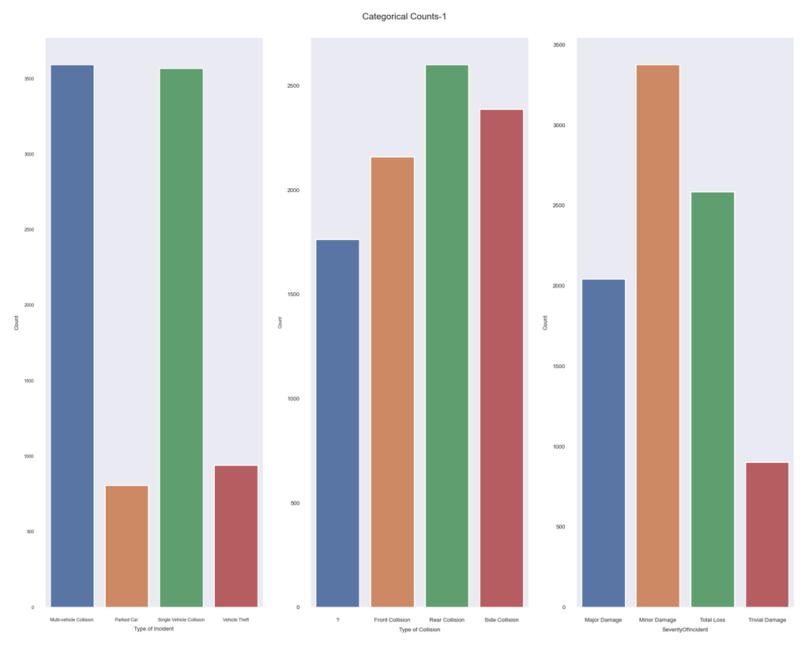

```python
gs=plt.GridSpec(1, 3)
fig=plt.figure(figsize=(10,8))
fig.suptitle('Categorical Counts-1', fontsize=8)


ax1=fig.add_subplot(gs[0, 0])
ax2=fig.add_subplot(gs[0, 1])
ax3=fig.add_subplot(gs[0,2])

#plt.title('Type of Incident',fontsize=7, y=1)
hg=sns.countplot(data = new_fraud_v3, x = 'TypeOfIncident', ax=ax1)
hg.tick_params(axis='both', which='major', labelsize=4)
hg.set_xlabel("Type of Incident", fontsize=5)
hg.set_ylabel("Count",fontsize=5)
#plt.title('Type of Collision',fontsize=7, y=1)
sp=sns.countplot(data=new_fraud_v3, x='TypeOfCollission', ax=ax2)
sp.tick_params(axis='both', which='major', labelsize=5)
sp.set_xlabel("Type of Collision", fontsize=5)
sp.set_ylabel("Count",fontsize=4)
#plt.title('Reported Fraud',fontsize=7, y=1)
bp=sns.countplot(data=new_fraud_v3, x='SeverityOfIncident', ax=ax3)
bp.tick_params(axis='both', which='major', labelsize=5)
bp.set_xlabel("SeverityOfIncident", fontsize=5)
bp.set_ylabel("Count", fontsize=5)

plt.tight_layout()

plt.show()
```

```python
plt.clf()
```

```python
my_tab=pd.crosstab(index=new_fraud_v3["TypeOfIncident"], columns=new_fraud_v3["TypeOfCollission"], normalize=True).round(2)
```

```python
fig = plt.figure(figsize=(13, 10))

sns.heatmap(my_tab, cmap="BuGn",cbar=False, annot=True,linewidth=0.3)

plt.yticks(rotation=0)
```

```
## (array([0.5, 1.5, 2.5, 3.5]), [Text(0, 0.5, 'Multi-vehicle Collision'), Text(0, 1.5, 'Parked Car'), Text(0, 2.5, 'Single Vehicle Collision'), Text(0, 3.5, 'Vehicle Theft')])
```

```python
plt.xticks(rotation=60)
```

```
## (array([0.5, 1.5, 2.5, 3.5]), [Text(0.5, 0, '?'), Text(1.5, 0, 'Front Collision'), Text(2.5, 0, 'Rear Collision'), Text(3.5, 0, 'Side Collision')])
```

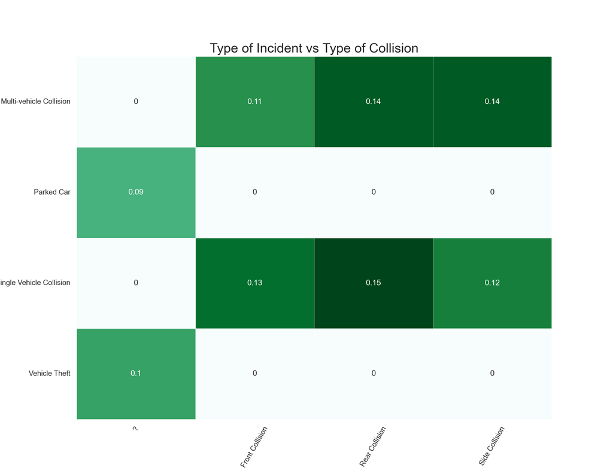

```python
plt.title('Type of Incident vs Type of Collision', fontsize=20)
plt.xlabel('TypeOfCollision', fontsize=15)
plt.ylabel('TypeOIncident', fontsize=15)

plt.show()
```

```python
plt.clf()
```

```python
new_fraud_v4=new_fraud_v3.copy()
```

```python
new_fraud_v4['TypeOfCollission'] = new_fraud_v4['TypeOfCollission'].replace(['?'], 'None')
```

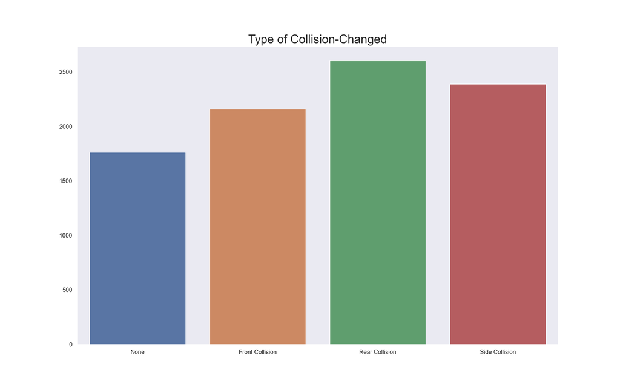

```python
plt.figure(figsize=(16,10))
#plt.title("Type of Collision-Changed")
ax=sns.countplot(data=new_fraud_v4, x='TypeOfCollission')
#plt.tick_params(label_rotation=45)
ax.tick_params(axis='both', which='major', labelsize=11)
ax.set_title("Type of Collision-Changed", size=22)
ax.set(xlabel=None)
ax.set(ylabel=None)
sns.set_style("dark")

ax.annotate('Figure ##',

            xy = (1.0, -0.2),

            xycoords='axes fraction',

            ha='right',

            va="center",

            fontsize=10)

fig.tight_layout()

plt.show()
```

```python
plt.clf()
```

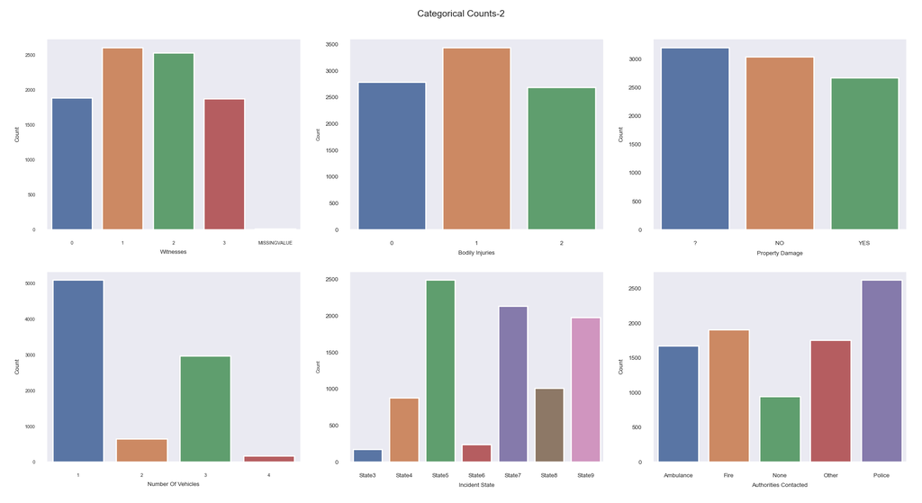

```python
gs=plt.GridSpec(2, 3)
fig=plt.figure(figsize=(11,6))
fig.suptitle('Categorical Counts-2', fontsize=8)


ax1=fig.add_subplot(gs[0, 0])
ax2=fig.add_subplot(gs[0, 1])
ax3=fig.add_subplot(gs[0,2])
ax4=fig.add_subplot(gs[1, 0])
ax5=fig.add_subplot(gs[1, 1])
ax6=fig.add_subplot(gs[1,2])

#plt.title('Type of Incident',fontsize=7, y=1)
c1=sns.countplot(data = new_fraud_v4, x = 'Witnesses', ax=ax1)
c1.tick_params(axis='both', which='major', labelsize=4)
c1.set_xlabel('Witnesses', fontsize=5)
c1.set_ylabel("Count",fontsize=5)
#plt.title('Type of Collision',fontsize=7, y=1)
c2=sns.countplot(data=new_fraud_v4, x='BodilyInjuries', ax=ax2)
c2.tick_params(axis='both', which='major', labelsize=5)
c2.set_xlabel("Bodily Injuries", fontsize=5)
c2.set_ylabel("Count",fontsize=4)
#plt.title('Reported Fraud',fontsize=7, y=1)
c3=sns.countplot(data=new_fraud_v4, x='PropertyDamage', ax=ax3)
c3.tick_params(axis='both', which='major', labelsize=5)
c3.set_xlabel("Property Damage", fontsize=5)
c3.set_ylabel("Count", fontsize=5)
c4=sns.countplot(data = new_fraud_v4, x = 'NumberOfVehicles', ax=ax4)
c4.tick_params(axis='both', which='major', labelsize=4)
c4.set_xlabel("Number Of Vehicles", fontsize=5)
c4.set_ylabel("Count",fontsize=5)
#plt.title('Type of Collision',fontsize=7, y=1)
c5=sns.countplot(data=new_fraud_v4, x='IncidentState', ax=ax5)
c5.tick_params(axis='both', which='major', labelsize=5)
c5.set_xlabel("Incident State", fontsize=5)
c5.set_ylabel("Count",fontsize=4)
#plt.title('Reported Fraud',fontsize=7, y=1)
c6=sns.countplot(data=new_fraud_v4, x='AuthoritiesContacted', ax=ax6)
c6.tick_params(axis='both', which='major', labelsize=5)
c6.set_xlabel("Authorities Contacted", fontsize=5)
c6.set_ylabel("Count", fontsize=5)

plt.tight_layout()

plt.show()
```

```python
plt.clf()
```

```python
new_fraud_v5=new_fraud_v4.copy()
```

```python
new_fraud_v5['Witnesses']=new_fraud_v5['Witnesses'].cat.remove_categories("MISSINGVALUE")
```

```python
new_fraud_v5=new_fraud_v5.drop(['PropertyDamage'], axis=1)
```

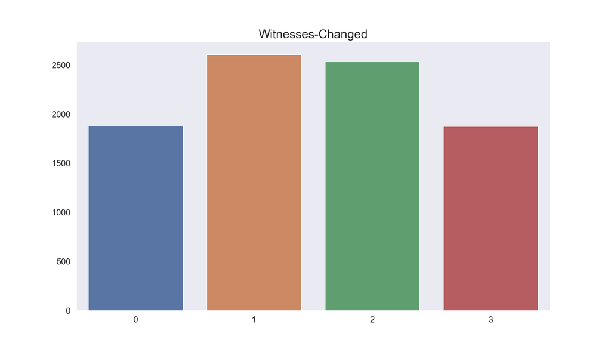

```python
plt.figure(figsize=(14,8))
#plt.title("Type of Collision-Changed")
ax=sns.countplot(data=new_fraud_v5, x='Witnesses')
#plt.tick_params(label_rotation=45)
ax.set_title("Witnesses-Changed", size=20)
ax.set(xlabel=None)
ax.set(ylabel=None)
ax.tick_params(axis='both', which='major', labelsize=14)
sns.set_style("dark")

ax.annotate('Figure ##',

            xy = (1.0, -0.2),

            xycoords='axes fraction',

            ha='right',

            va="center",

            fontsize=10)

fig.tight_layout()

plt.show()
```

```python
plt.clf()
```

```python
new_fraud_v5.isna().sum() > 0
```

```
## CustomerID                    False
## TypeOfIncident                False
## TypeOfCollission              False
## SeverityOfIncident            False
## AuthoritiesContacted          False
## IncidentState                 False
## IncidentCity                  False
## IncidentAddress               False
## NumberOfVehicles              False
## BodilyInjuries                False
## Witnesses                      True
## PoliceReport                  False
## AmountOfTotalClaim             True
## AmountOfInjuryClaim           False
## AmountOfPropertyClaim         False
## AmountOfVehicleDamage         False
## InsuredAge                    False
## InsuredZipCode                False
## InsuredGender                  True
## InsuredEducationLevel         False
## InsuredOccupation             False
## InsuredHobbies                False
## CapitalGains                  False
## CapitalLoss                   False
## Country                        True
## InsurancePolicyNumber         False
## CustomerLoyaltyPeriod         False
## InsurancePolicyState          False
## Policy_CombinedSingleLimit    False
## Policy_Deductible             False
## PolicyAnnualPremium           False
## UmbrellaLimit                 False
## InsuredRelationship           False
## coverageIncidentDiff          False
## dayOfWeek                     False
## IncidentPeriodDay              True
## dtype: bool
```

From the above output we find there are features containing null (missing) values. Before we remove any missing values, we’ll droop features that will not be used in our models.

```python
new_fraud_v6=new_fraud_v5.copy()
```

```python
new_fraud_v6=new_fraud_v6.drop(['CustomerID', 'IncidentAddress', 'InsuredZipCode', 'InsuredHobbies','Country', 'InsurancePolicyNumber', 'IncidentCity','AmountOfInjuryClaim', 'AmountOfPropertyClaim', 'AmountOfVehicleDamage',
  'InsuredEducationLevel','InsuredOccupation','PoliceReport'], axis=1)
```

```python
new_fraud_v6.isna().sum()
```

```
## TypeOfIncident                  0
## TypeOfCollission                0
## SeverityOfIncident              0
## AuthoritiesContacted            0
## IncidentState                   0
## NumberOfVehicles                0
## BodilyInjuries                  0
## Witnesses                      12
## AmountOfTotalClaim              8
## InsuredAge                      0
## InsuredGender                   8
## CapitalGains                    0
## CapitalLoss                     0
## CustomerLoyaltyPeriod           0
## InsurancePolicyState            0
## Policy_CombinedSingleLimit      0
## Policy_Deductible               0
## PolicyAnnualPremium             0
## UmbrellaLimit                   0
## InsuredRelationship             0
## coverageIncidentDiff            0
## dayOfWeek                       0
## IncidentPeriodDay             107
## dtype: int64
```

```python
new_fraud_v7=new_fraud_v6.copy()
```

```python
new_fraud_v7=new_fraud_v7.dropna()
```

```python
new_fraud_v7.isna().sum()
```

```
## TypeOfIncident                0
## TypeOfCollission              0
## SeverityOfIncident            0
## AuthoritiesContacted          0
## IncidentState                 0
## NumberOfVehicles              0
## BodilyInjuries                0
## Witnesses                     0
## AmountOfTotalClaim            0
## InsuredAge                    0
## InsuredGender                 0
## CapitalGains                  0
## CapitalLoss                   0
## CustomerLoyaltyPeriod         0
## InsurancePolicyState          0
## Policy_CombinedSingleLimit    0
## Policy_Deductible             0
## PolicyAnnualPremium           0
## UmbrellaLimit                 0
## InsuredRelationship           0
## coverageIncidentDiff          0
## dayOfWeek                     0
## IncidentPeriodDay             0
## dtype: int64
```

All null values have been removed from our data.

```python
new_fraud_v7[new_fraud_v7['PolicyAnnualPremium']==-1].shape
```

```
## (47, 23)
```

-1 level in Policy Annual Premium represents missing values.

```python
new_fraud_v8=new_fraud_v8[new_fraud_v8['PolicyAnnualPremium']!=-1]
```

```python
new_fraud_v8[new_fraud_v8['PolicyAnnualPremium']==-1].shape
```

```
## (0, 23)
```

The PolicyAnnualPremium feature now has no missing features (category -1).

## Data Preparation

First step is to confirm our new data **new_fraud_v8** has the same columns as our training data. We’ll then check if the levels of our categorical columns of both data frames are equal.

```python
new_data=new_fraud_v8.copy()
```

```python
print("X_train and new_data columns are equal:",X_train.columns.equals(new_data.columns))
```

```
## X_train and new_data columns are equal: True
```

```python
categorical, numerical=define_columns(new_data)
```

```
## Categorical Features:  ['TypeOfIncident', 'TypeOfCollission', 'SeverityOfIncident', 'AuthoritiesContacted', 'IncidentState', 'NumberOfVehicles', 'BodilyInjuries', 'Witnesses', 'InsuredGender', 'InsurancePolicyState', 'Policy_CombinedSingleLimit', 'InsuredRelationship', 'dayOfWeek', 'IncidentPerio…
```

```
## numerical Features:  ['AmountOfTotalClaim', 'InsuredAge', 'CapitalGains', 'CapitalLoss', 'CustomerLoyaltyPeriod', 'Policy_Deductible', 'PolicyAnnualPremium', 'UmbrellaLimit', 'coverageIncidentDiff']
```

Let’s check that the levels from the new data new_fraud_v8 are the same as those categorical levels from the X_train data.

```python
def assert_categorical_levels_match(df1, df2, categorical_columns):
    """
    Checks if the unique values (levels) of categorical columns in two DataFrames match.

    Parameters:
    df1 (pd.DataFrame): First DataFrame
    df2 (pd.DataFrame): Second DataFrame
    categorical_columns (list): List of categorical column names to compare

    Raises:
    AssertionError: If any categorical column has mismatched levels between the two DataFrames.
    """
    for col in categorical_columns:
        levels_df1 = set(df1[col].unique())
        levels_df2 = set(df2[col].unique())

        assert levels_df1 == levels_df2, f"Mismatch in column '{col}': {levels_df1 ^ levels_df2}"

    print("All categorical column levels match.")
```

```python
assert_categorical_levels_match(X_train, new_data,categorical)
```

```
## All categorical column levels match.
```

Now that we have confirmed categorical levels of both data frames match we can now transform them in preparation of fitting our model.

```python
X_train_tr, X_new=transform_x_columns_tr(X_train, new_data)
```

```
## Rows of First three Columns
##     num__AmountOfTotalClaim  num__InsuredAge  num__CapitalGains
## 0                 0.639019        -1.489358           1.199641
## 1                 0.121226         0.141468           1.210473
## 2                 0.289220         0.016020           0.260888
## 3                -1.870518        -0.109428           1.636523
## 4                -0.694800        -1.238462           0.430586
```

## Test Model

```python
import unittest
```

```python
model=xgb_base_clf
```

```python
X_test=X_new.copy()
```

Our next step is to test the XGBoost classifier on our new data to ensure that it returns the expected outputs of [0,1] and returns probabilities bewtween 0 and 1.

```python
test_results = []
```

```python
# Define a test class with CSV logging
class TestModelInference(unittest.TestCase):
    def setUp(self):
        self.model = model
        self.X_test = X_test

    def test_prediction_output_values(self):
        """Test that model predictions contain only valid class labels."""
        start_time = time.time()
        pred = self.model.predict(self.X_test)
        unique_values = np.unique(pred)
        for value in unique_values:
            self.assertIn(value, [0, 1])
        elapsed_time = time.time() - start_time
        test_results.append(["Prediction Output Values", "Pass", round(elapsed_time, 4)])

    def test_prediction_probabilities(self):
        """Test that the model returns valid probability values between 0 and 1."""
        start_time = time.time()
        prob_pred = self.model.predict_proba(self.X_test)
        self.assertTrue(np.all((prob_pred >= 0) & (prob_pred <= 1)), "Probabilities must be between 0 and            1")
        self.assertTrue(np.allclose(prob_pred.sum(axis=1), 1, atol=1e-6), "Sum of probabilities must be             close to 1")
        elapsed_time = time.time() - start_time
        test_results.append(["Prediction Probabilities", "Pass", round(elapsed_time, 4)])
    def test_prediction_time(self):
        """Test that the model predicts within an acceptable time limit."""
        start_time = time.time()
        _ = self.model.predict(self.X_test)
        elapsed_time = time.time() - start_time
        self.assertLess(elapsed_time, 1, f"Prediction took too long: {elapsed_time:.4f} seconds")
        test_results.append(["Prediction Time", "Pass" if elapsed_time < 1 else "Fail", round(elapsed_time,          4)])
```

```python
# Run tests and capture results
if __name__ == "__main__":
    print("\n===== Running Model Tests =====\n")

    # Redirect unittest output to a buffer
    test_buffer = StringIO()
    runner = unittest.TextTestRunner(stream=test_buffer, verbosity=2)
    unittest.main(argv=['model;, x_test'], exit=False, testRunner=runner)

    # Convert test results to a DataFrame
    df_results = pd.DataFrame(test_results, columns=["Test Name", "Status", "Execution Time (s)"])

    # Save results to CSV
    df_results.to_csv("test_results.csv", index=False)

    print("\nTest results saved to test_results.csv")
```

```
##
## ===== Running Model Tests =====
##
## <unittest.main.TestProgram object at 0x3aa2b3610>
##
## Test results saved to test_results.csv
```

Model Test Results

| Test.Name | Status | Execution.Time..s. |
| --- | --- | --- |
| Prediction Output Values | Pass | 0.0039 |
| Prediction Probabilities | Pass | 0.0033 |
| Prediction Time | Pass | 0.0036 |

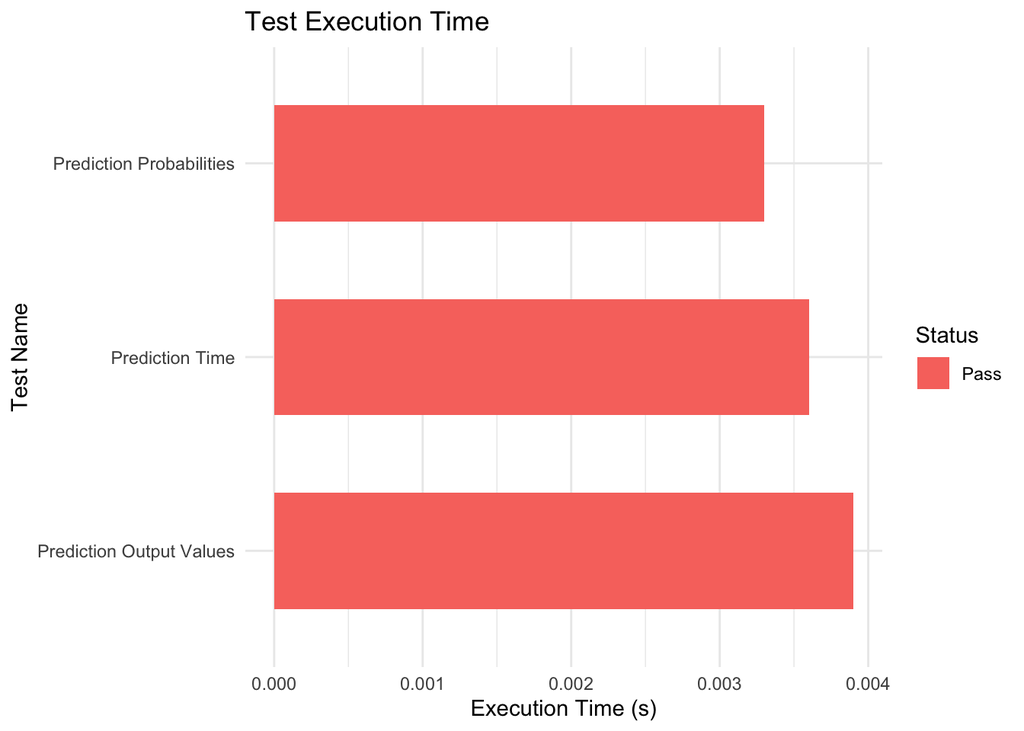

Our classifier passed the tests. Now we will use the classifier to predict on the new data.

## Predict and Evaluate

```python
xg_predictions=xgb_base_clf.predict(X_new)
```

```python
xg_results_df = new_data.copy()
xg_results_df["Predicted_Label"] = xg_predictions
```

Let’s compare our predicted labels(fraud) of the new data to the reported fraud in our original data.

```
## Predicted Fraud Percentages from New Data:
## 0    0.85
## 1    0.15
## Name: Predicted_Label, dtype: float64
```

```
## Reported Fraud Percentages from Original Data:
## N    0.73
## Y    0.27
## Name: ReportedFraud, dtype: float64
```

The results show that our model predicted 15% of our observations as fraud compared to 27% of the original data reported as fraud. This is a 12% difference. Let’s check the prediction results on our original test data.

```python
xg_test_predictions=xgb_base_clf.predict(X_test_tr)
```

```python
xg_test_results_df = X_test_tr.copy()
```

```python
xg_test_results_df["Predicted_Label"] = xg_test_predictions
```

```python
test_count=xg_test_results_df["Predicted_Label"].value_counts(normalize=True).round(2)
```

```
## Reported Fraud Percentages from Original Data:
## 0    0.77
## 1    0.23
## Name: Predicted_Label, dtype: float64
```

The predicted labels of the test data are closer to the the original data than the those from the new data.

Let’s take a look at the predicted probabilities for both the new and test data.

```python
xg_probs_new=xgb_base_clf.predict_proba(X_new)
```

```python
xg_probs_df = pd.DataFrame(xg_probs_new, columns=['fraud_no', 'fraud_yes'])
```

```
## First Five Rows of xg_probs_df
##     fraud_no  fraud_yes
## 0  0.990794   0.009206
## 1  0.877024   0.122976
## 2  0.873884   0.126116
## 3  0.909902   0.090098
## 4  0.926205   0.073795
```

```python
xg_probs_test=xgb_base_clf.predict_proba(X_test_tr)
```

```python
xg_test_probs_df = pd.DataFrame(xg_probs_test, columns=['fraud_no', 'fraud_yes'])
```

```
## First Five Rows of xg_test_probs_df
##     fraud_no  fraud_yes
## 0  0.149526   0.850474
## 1  0.932576   0.067424
## 2  0.027026   0.972974
## 3  0.922639   0.077361
## 4  0.956429   0.043571
```

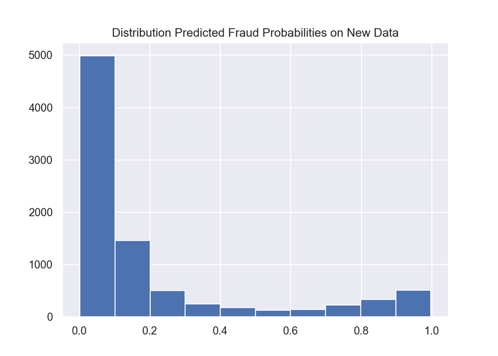

```python
xg_probs_df["fraud_yes"].hist()
plt.title("Distribution Predicted Fraud Probabilities on New Data")
plt.show()
```

```python
plt.clf()
```

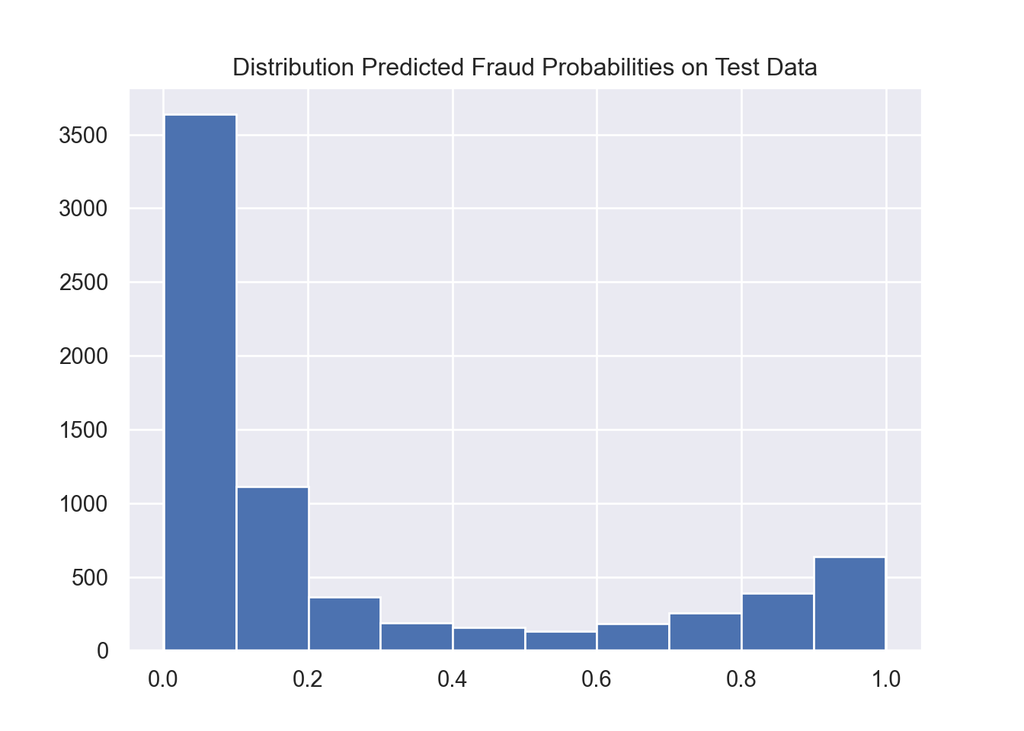

```python
xg_test_probs_df["fraud_yes"].hist()
plt.title("Distribution Predicted Fraud Probabilities on Test Data")
plt.show()
```

```python
plt.clf()
```

The distributions appear similar. We are interested in predicted probabilities of 50% or greater. The xg boost classifier appears to be marginally stronger at predicting reported fraud of yes on the original test data at probabilities of 70% or higher. We’ll filter our data to observe just predicted probabilities of fraud over 70%.

```python
xg_probs_ovr_sventyPct=xg_probs_ovr_sventyPct[xg_probs_ovr_sventyPct.fraud_yes >= 0.7]
```

```python
new_probs_PctOvrSvnty=len(xg_probs_ovr_sventyPct)/len(xg_probs_df)*100
```

```python
xg_test_probs_ovr_svntyPct=xg_test_probs_df.copy()
```

```python
xg_test_probs_ovr_svntyPct=xg_test_probs_ovr_svntyPct[xg_test_probs_ovr_svntyPct.fraud_yes >=0.7]
```

```python
test_probs_PctOvrSvnty=len(xg_test_probs_ovr_svntyPct) / len(xg_test_probs_df)*100
```

[output not shown]

It appears the xg boost classifier predicted a higher percentage of fraud on the original test set than on our new data. Assessment on the xg boost classifier would benefit from collecting additional data before a definitive judgement can be made.